# Bias and Error in Herbarium data

What about data we did not georeference?

```r
M100Y_lmg3<- lm(DOY ~ MAT_100Y + MAP_100Y, data = nemo_ngeo)
M100Y_lmg4<- lm(DOY ~ MAT_100Y + MAP_100Y + elev_m + long + year, data = nemo_ngeo)
summary(M100Y_lmg3)
```

```
##
## Call:
## lm(formula = DOY ~ MAT_100Y + MAP_100Y, data = nemo_ngeo)
##
## Residuals:
##     Min      1Q  Median      3Q     Max
## -96.148 -17.231  -0.139  16.447 114.096
##
## Coefficients:
##             Estimate Std. Error t value Pr(>|t|)
## (Intercept) 169.9929    17.4054   9.767   <2e-16 ***
## MAT_100Y     -6.3133     0.5185 -12.175   <2e-16 ***
## MAP_100Y      4.7038     1.8897   2.489   0.0129 *
## ---
## Signif. codes:  0 '***' 0.001 '**' 0.01 '*' 0.05 '.' 0.1 ' ' 1
##
## Residual standard error: 26.87 on 1236 degrees of freedom
## Multiple R-squared:  0.178,  Adjusted R-squared:  0.1766
## F-statistic: 133.8 on 2 and 1236 DF,  p-value: < 2.2e-16
```

```r
summary(M100Y_lmg4)
```

```
##
## Call:
## lm(formula = DOY ~ MAT_100Y + MAP_100Y + elev_m + long + year,
##     data = nemo_ngeo)
##
## Residuals:
##     Min      1Q  Median      3Q     Max
## -85.406 -14.941  -0.119  14.773 148.056
##
## Coefficients:
##               Estimate Std. Error t value Pr(>|t|)
## (Intercept) 311.137068  83.173009   3.741 0.000192 ***
## MAT_100Y     -1.103539   0.716571  -1.540 0.123810
## MAP_100Y     16.173218   1.950135   8.293 2.85e-16 ***
## elev_m        0.024243   0.002854   8.496  < 2e-16 ***
## long          1.469784   0.548549   2.679 0.007473 **
## year         -0.068257   0.021461  -3.180 0.001507 **
## ---
## Signif. codes:  0 '***' 0.001 '**' 0.01 '*' 0.05 '.' 0.1 ' ' 1
##
## Residual standard error: 24.5 on 1233 degrees of freedom
## Multiple R-squared:  0.3182, Adjusted R-squared:  0.3154
## F-statistic: 115.1 on 5 and 1233 DF,  p-value: < 2.2e-16
```

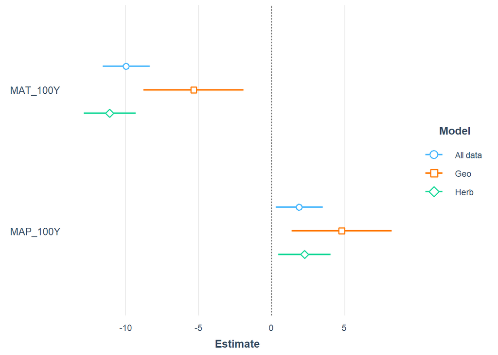

```r
plot_summs(M100Y_lm1, M100Y_lmg1, M100Y_lmg3, model.names = c("All data", "Geo", "Herb"), scale = TRUE)
```

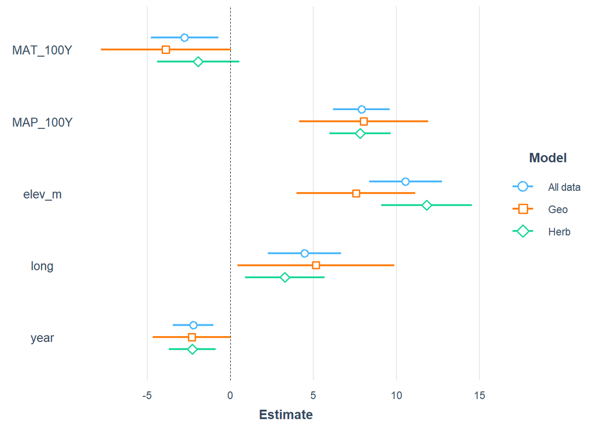

```r
plot_summs(M100Y_lm2, M100Y_lmg2, M100Y_lmg4, model.names = c("All data", "Geo", "Herb"), scale = TRUE)
```

Winter Conditions

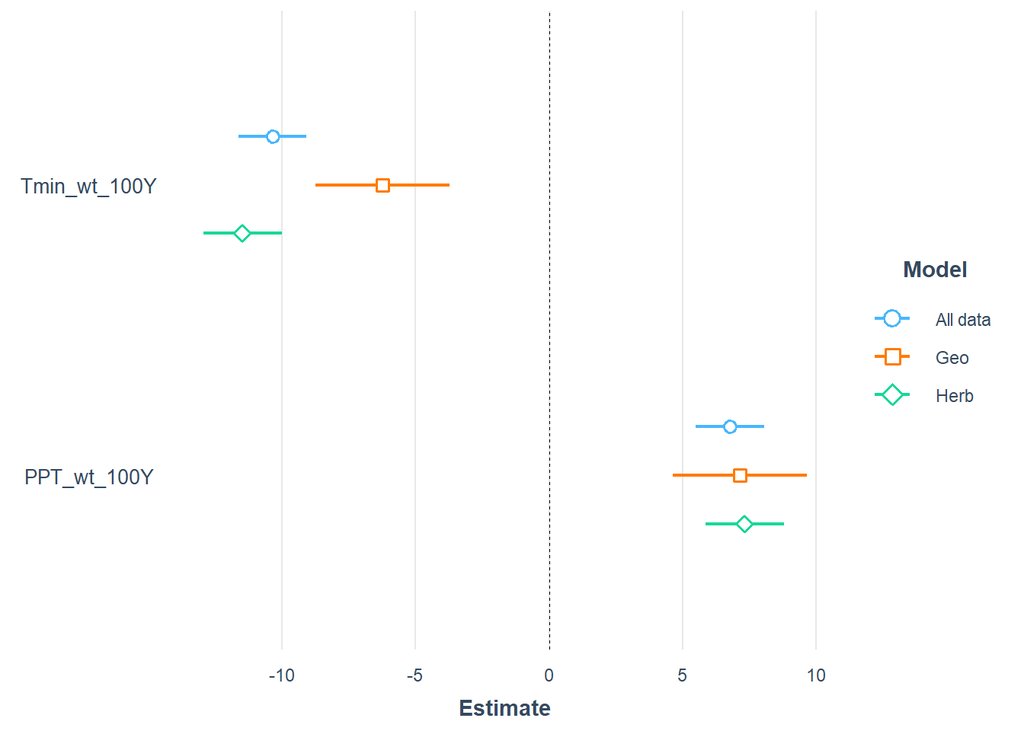

```r
#Climate-only
Wt100Y_lmg1 <- lm(DOY ~ Tmin_wt_100Y + PPT_wt_100Y, data = nemo_geor)
Wt100Y_lmg3<- lm(DOY ~ Tmin_wt_100Y + PPT_wt_100Y, data = nemo_ngeo)

#Interactions
Wt100Y_lmg1i <- lm(DOY ~ Tmin_wt_100Y*PPT_wt_100Y, data = nemo_geor)
Wt100Y_lmg3i<- lm(DOY ~ Tmin_wt_100Y*PPT_wt_100Y, data = nemo_ngeo)


#Other predictors
Wt100Y_lmg2 <- lm(DOY ~ Tmin_wt_100Y + PPT_wt_100Y + elev_m + long + year, data = nemo_geor)
Wt100Y_lmg4<- lm(DOY ~ Tmin_wt_100Y + PPT_wt_100Y + elev_m + long + year, data = nemo_ngeo)


plot_summs(Wt100Y_lm1, Wt100Y_lmg1, Wt100Y_lmg3, model.names = c("All data", "Geo", "Herb"), scale = TRUE)
```

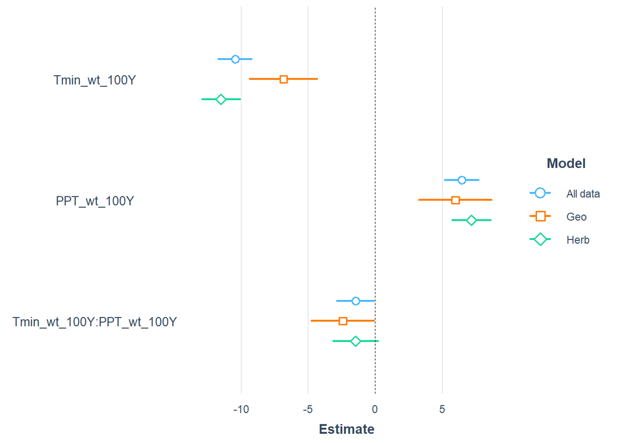

```r
plot_summs(Wt100Y_lm1i, Wt100Y_lmg1i, Wt100Y_lmg3i, model.names = c("All data", "Geo", "Herb"), scale = TRUE)
```

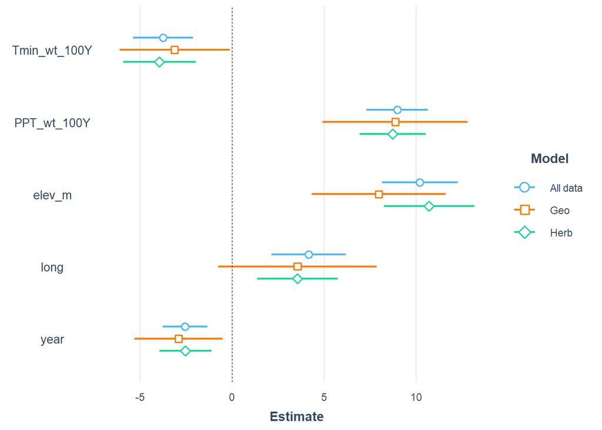

```r
plot_summs(Wt100Y_lm2, Wt100Y_lmg2, Wt100Y_lmg4, model.names = c("All data", "Geo", "Herb"), scale = TRUE)
```

```r
summary(Wt100Y_lmg1)
summary(Wt100Y_lmg3)
summary(Wt100Y_lmg1i)
summary(Wt100Y_lmg3i)
summary(Wt100Y_lmg2)
summary(Wt100Y_lmg4)
```

Spring Conditions

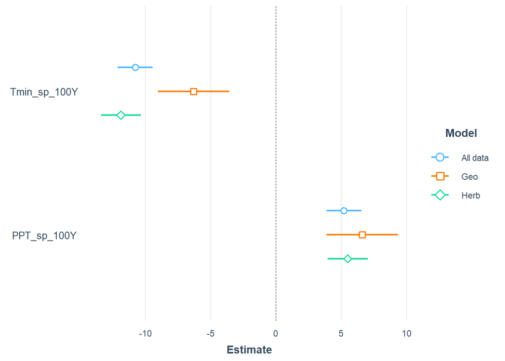

```r
#Climate-only
Sp100Y_lmg1 <- lm(DOY ~ Tmin_sp_100Y + PPT_sp_100Y, data = nemo_geor)
Sp100Y_lmg3<- lm(DOY ~ Tmin_sp_100Y + PPT_sp_100Y, data = nemo_ngeo)

#Interactions
Sp100Y_lmg1i <- lm(DOY ~ Tmin_sp_100Y*PPT_sp_100Y, data = nemo_geor)
Sp100Y_lmg3i<- lm(DOY ~ Tmin_sp_100Y*PPT_sp_100Y, data = nemo_ngeo)


#Other predictors
Sp100Y_lmg2 <- lm(DOY ~ Tmin_sp_100Y + PPT_sp_100Y + elev_m + long + year, data = nemo_geor)
Sp100Y_lmg4<- lm(DOY ~ Tmin_sp_100Y + PPT_sp_100Y + elev_m + long + year, data = nemo_ngeo)


plot_summs(Sp100Y_lm1, Sp100Y_lmg1, Sp100Y_lmg3, model.names = c("All data", "Geo", "Herb"), scale = TRUE)
```

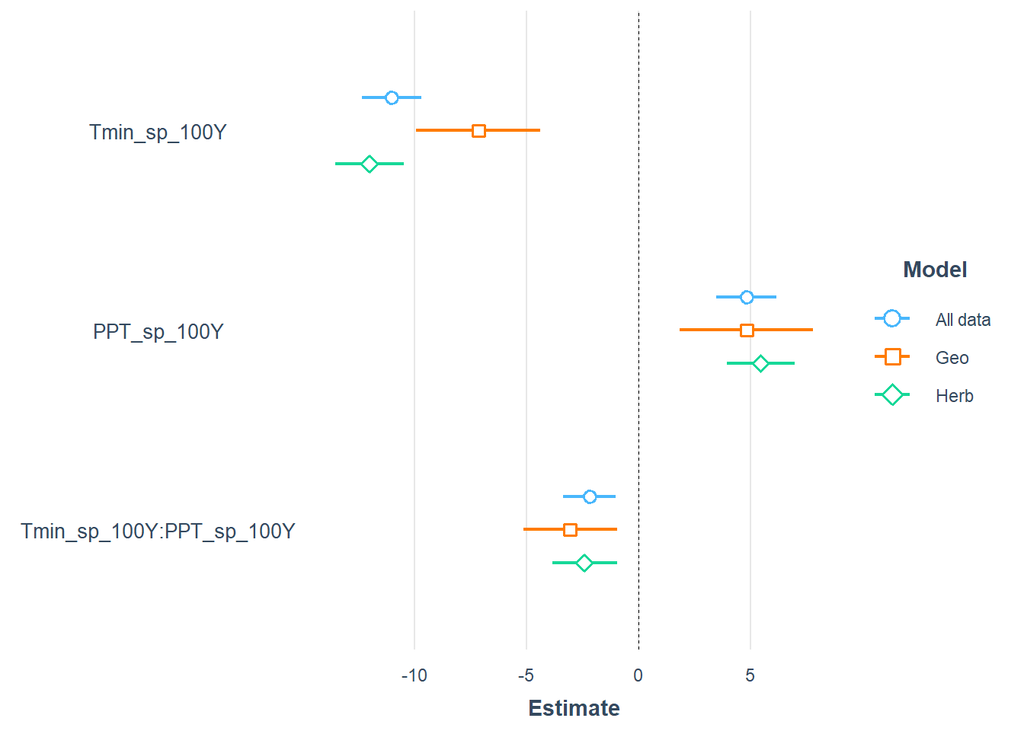

```r
plot_summs(Sp100Y_lm1i, Sp100Y_lmg1i, Sp100Y_lmg3i, model.names = c("All data", "Geo", "Herb"), scale = TRUE)
```

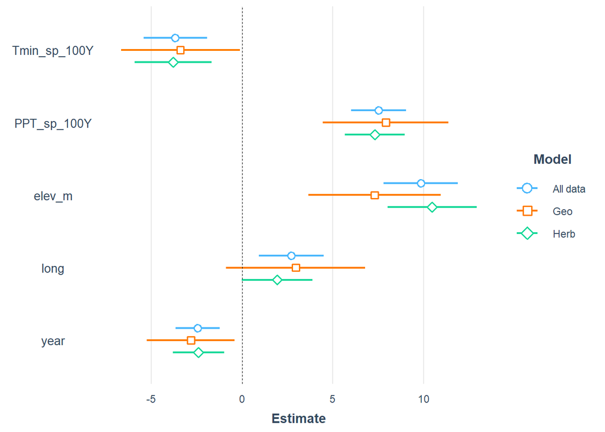

```r
plot_summs(Sp100Y_lm2, Sp100Y_lmg2, Sp100Y_lmg4, model.names = c("All data", "Geo", "Herb"), scale = TRUE)
```

```r
summary(Sp100Y_lmg1)
summary(Sp100Y_lmg3)
summary(Sp100Y_lmg1i)
summary(Sp100Y_lmg3i)
summary(Sp100Y_lmg2)
summary(Sp100Y_lmg4)
```

Ours still seem a little more variable (and NS in a couple cases), but are quite similar to herbarium-georeferenced data. It looks like our manually referenced specimens produce a **smaller sensitivity to long-term temperature**, but this becomes non-significant when geography is accounted for. Most likely due to a smaller sample size of records we georeferenced, though we may have been less accurate than others.

```r
#Georef_by as a covariate
nemo_gby <- nemo_df2 %>%
  mutate(geo_f = as_factor(case_when(!is.na(georef_by) ~ "y",
                           is.na(georef_by) ~ "n")))

M100Y_lmg3b <- lm(DOY ~ MAT_100Y + MAP_100Y + geo_f, data = nemo_gby)
M100Y_lmg4b <- lm(DOY ~ MAT_100Y + MAP_100Y + elev_m + long + year + geo_f, data = nemo_gby)

summary(M100Y_lmg3b)
```

```
##
## Call:
## lm(formula = DOY ~ MAT_100Y + MAP_100Y + geo_f, data = nemo_gby)
##
## Residuals:
##     Min      1Q  Median      3Q     Max
## -94.973 -17.396  -0.223  16.645 116.279
##
## Coefficients:
##             Estimate Std. Error t value Pr(>|t|)
## (Intercept) 147.2170    15.5337   9.477  < 2e-16 ***
## MAT_100Y     -5.5271     0.4568 -12.101  < 2e-16 ***
## MAP_100Y      5.2473     1.6256   3.228  0.00127 **
## geo_fn        7.5860     1.5322   4.951 8.13e-07 ***
## ---
## Signif. codes:  0 '***' 0.001 '**' 0.01 '*' 0.05 '.' 0.1 ' ' 1
##
## Residual standard error: 26.92 on 1673 degrees of freedom
## Multiple R-squared:  0.1584, Adjusted R-squared:  0.1569
## F-statistic:   105 on 3 and 1673 DF,  p-value: < 2.2e-16
```

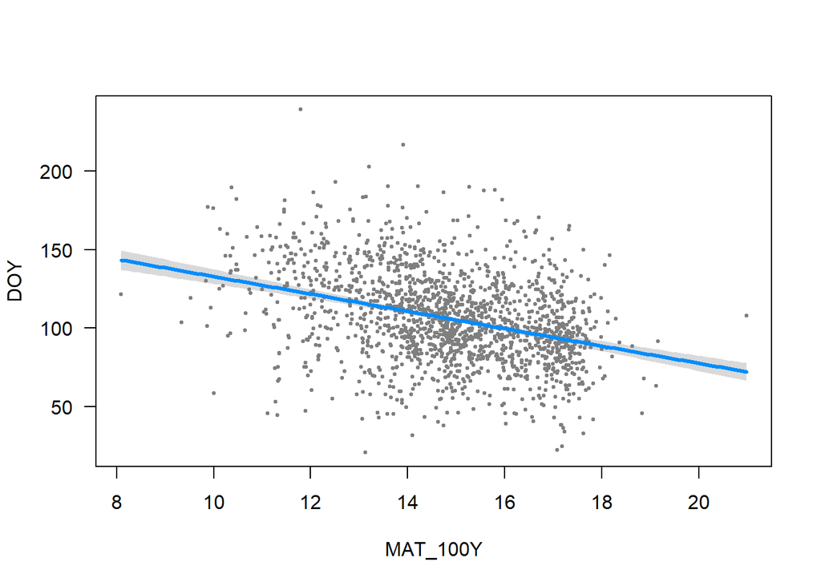

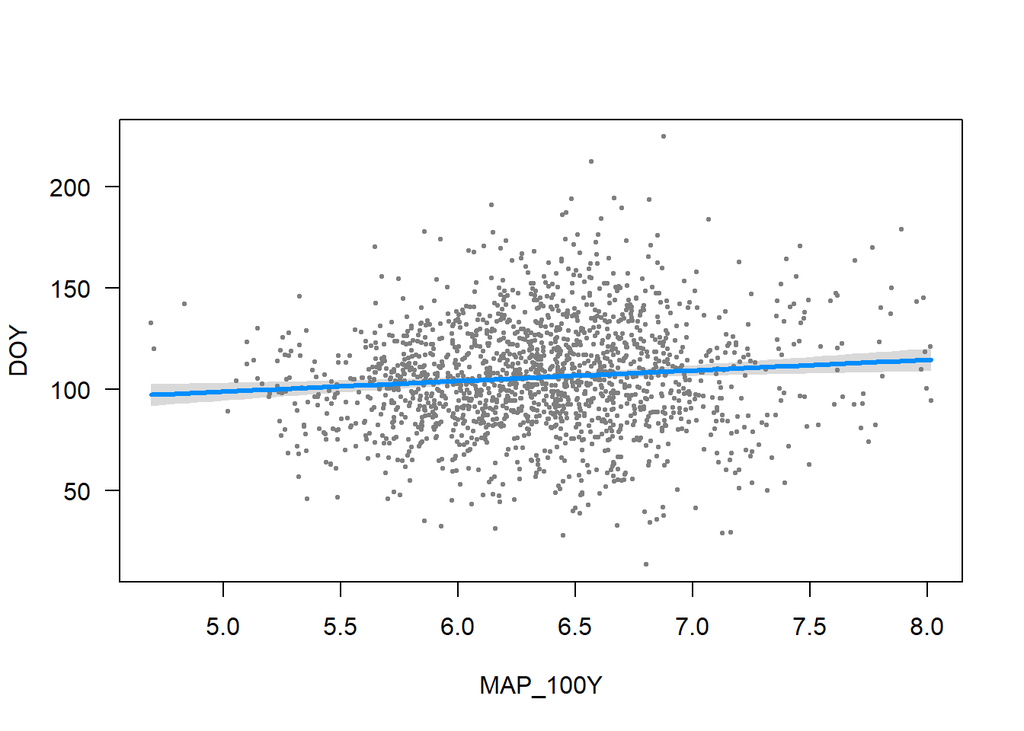

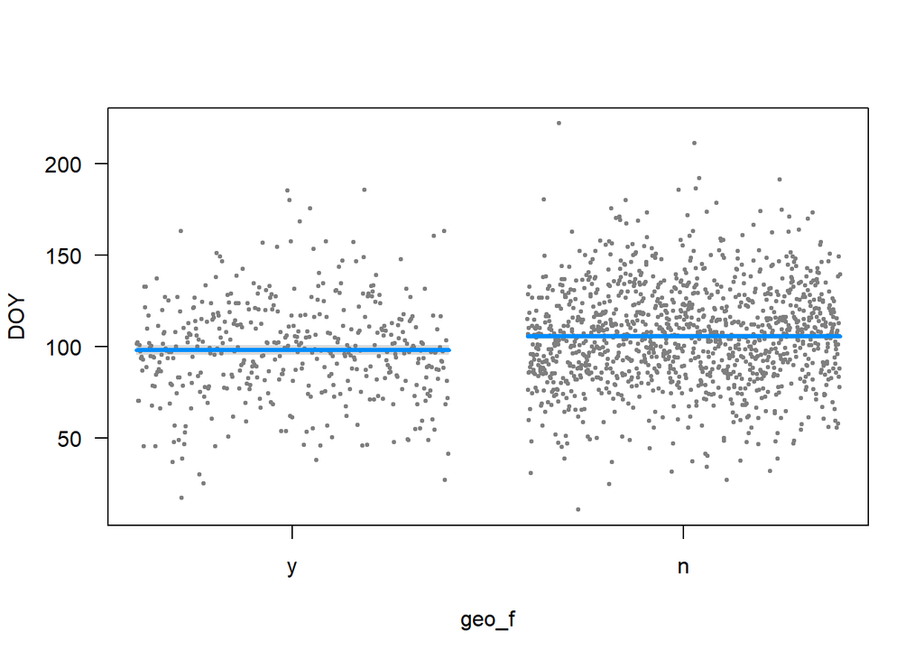

```r
visreg(M100Y_lmg3b)
```

```r
summary(M100Y_lmg4b)
```

```
##
## Call:
## lm(formula = DOY ~ MAT_100Y + MAP_100Y + elev_m + long + year +
##     geo_f, data = nemo_gby)
##
## Residuals:
##     Min      1Q  Median      3Q     Max
## -84.392 -14.883  -0.033  14.895 146.933
##
## Coefficients:
##               Estimate Std. Error t value Pr(>|t|)
## (Intercept) 367.666451  71.490205   5.143 3.02e-07 ***
## MAT_100Y     -1.549736   0.582253  -2.662 0.007851 **
## MAP_100Y     15.480091   1.699546   9.108  < 2e-16 ***
## elev_m        0.021867   0.002319   9.429  < 2e-16 ***
## long          1.793763   0.479302   3.742 0.000188 ***
## year         -0.071658   0.019223  -3.728 0.000200 ***
## geo_fn        1.418739   1.474755   0.962 0.336180
## ---
## Signif. codes:  0 '***' 0.001 '**' 0.01 '*' 0.05 '.' 0.1 ' ' 1
##
## Residual standard error: 24.55 on 1670 degrees of freedom
## Multiple R-squared:  0.3014, Adjusted R-squared:  0.2989
## F-statistic: 120.1 on 6 and 1670 DF,  p-value: < 2.2e-16
```

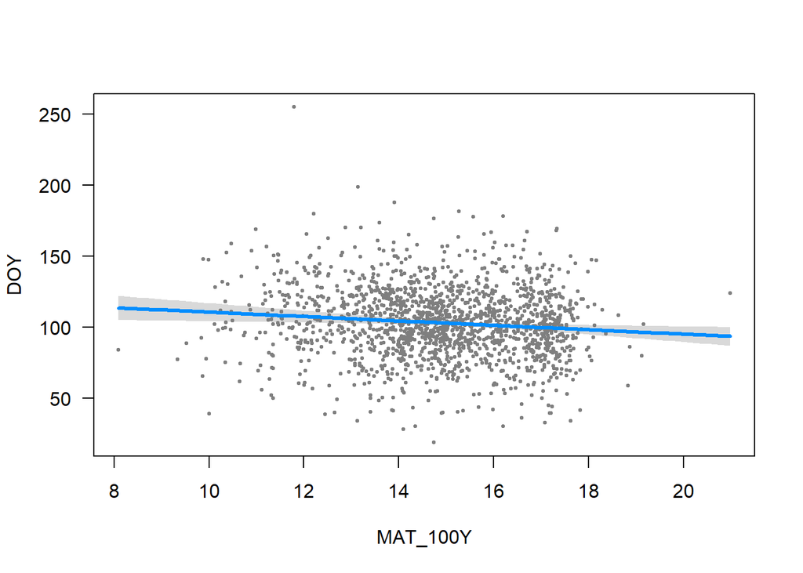

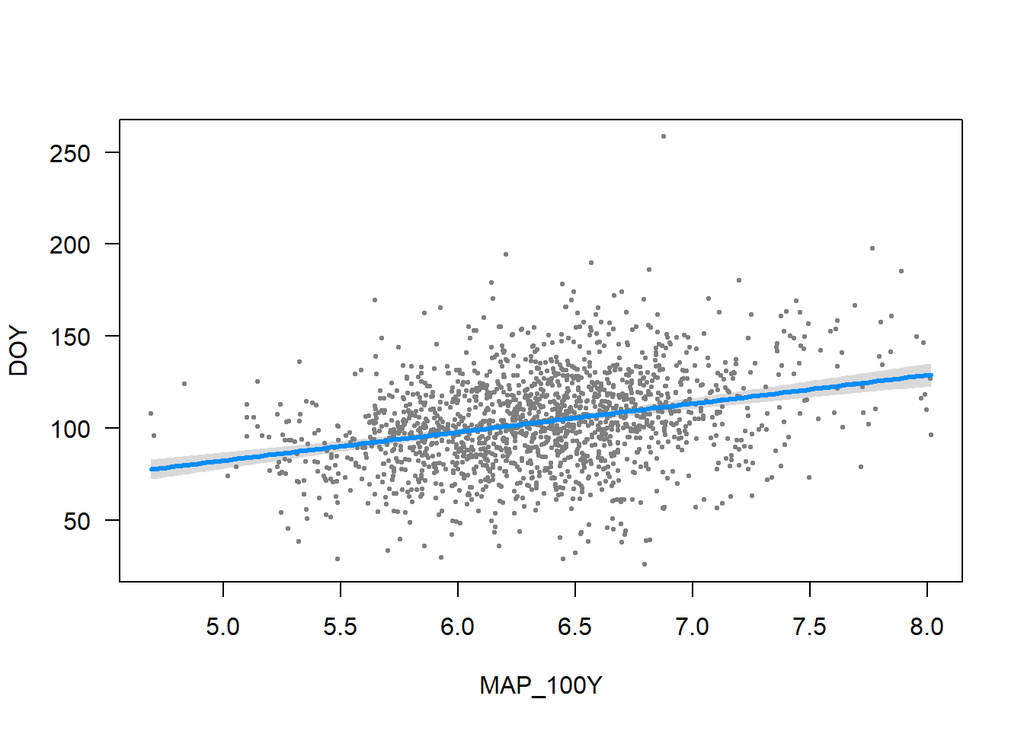

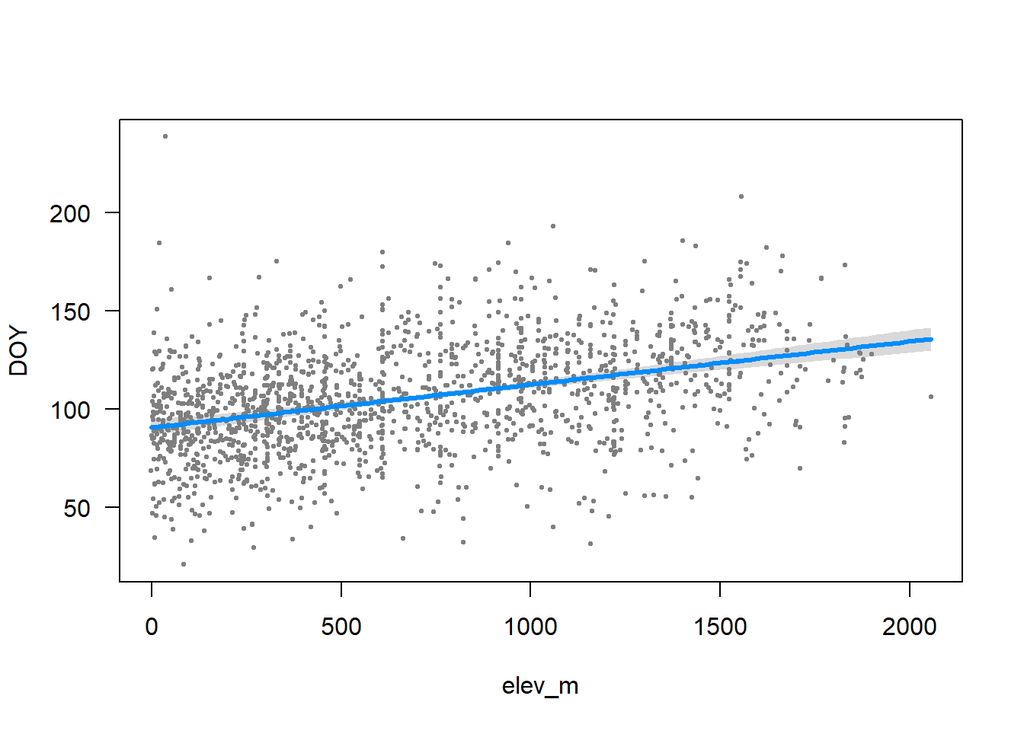

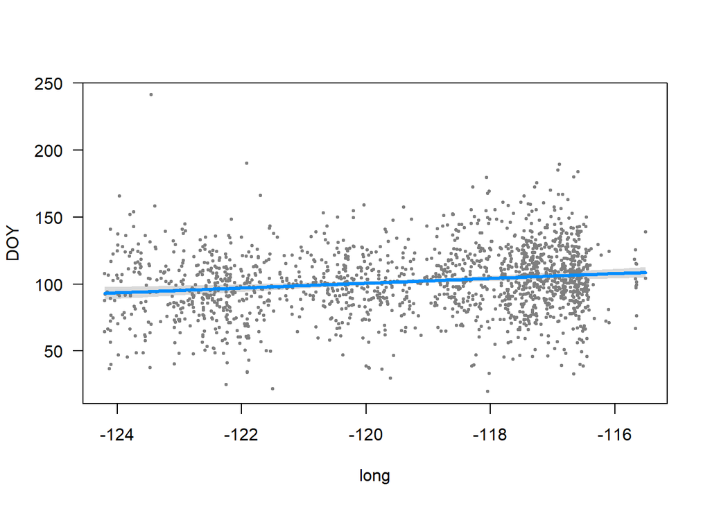

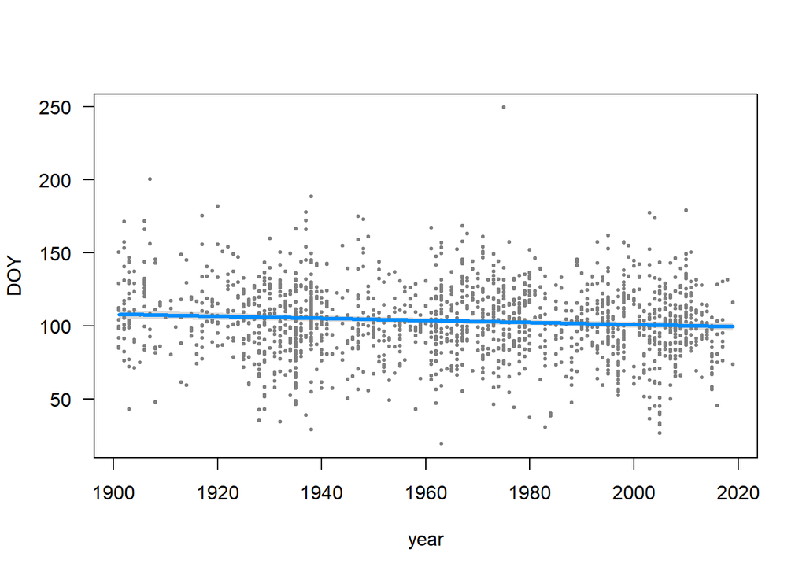

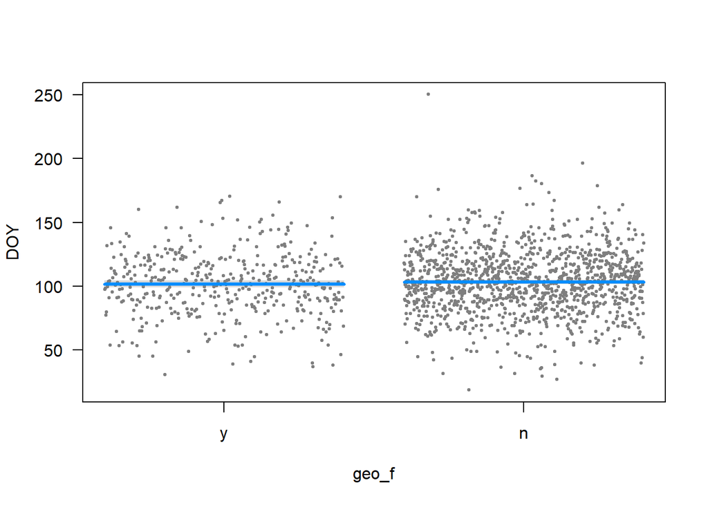

```r
visreg(M100Y_lmg4b)
```

```r
#Interactions
M100Y_lmg3bi <- lm(DOY ~ MAT_100Y + MAP_100Y + geo_f + geo_f:MAT_100Y, data = nemo_gby)
#M100Y_lmg4bi <- lm(DOY ~ MAT_100Y + MAP_100Y + elev_m + long + year + geo_f + geo_f:MAT_100Y, data = nemo_gby) #No interaction here

summary(M100Y_lmg3bi)
```

```
##
## Call:
## lm(formula = DOY ~ MAT_100Y + MAP_100Y + geo_f + geo_f:MAT_100Y,
##     data = nemo_gby)
##
## Residuals:
##     Min      1Q  Median      3Q     Max
## -96.402 -16.867  -0.197  16.298 113.978
##
## Coefficients:
##                 Estimate Std. Error t value Pr(>|t|)
## (Intercept)     115.2487    18.5855   6.201 7.05e-10 ***
## MAT_100Y         -3.5635     0.7779  -4.581 4.97e-06 ***
## MAP_100Y          5.7688     1.6301   3.539 0.000413 ***
## geo_fn           45.6549    12.3191   3.706 0.000217 ***
## MAT_100Y:geo_fn  -2.5900     0.8317  -3.114 0.001875 **
## ---
## Signif. codes:  0 '***' 0.001 '**' 0.01 '*' 0.05 '.' 0.1 ' ' 1
##
## Residual standard error: 26.85 on 1672 degrees of freedom
## Multiple R-squared:  0.1633, Adjusted R-squared:  0.1613
## F-statistic: 81.58 on 4 and 1672 DF,  p-value: < 2.2e-16
```

```r
visreg(M100Y_lmg3bi)
```

```
## Conditions used in construction of plot
## MAP_100Y: 6.348667
## geo_f: n
```

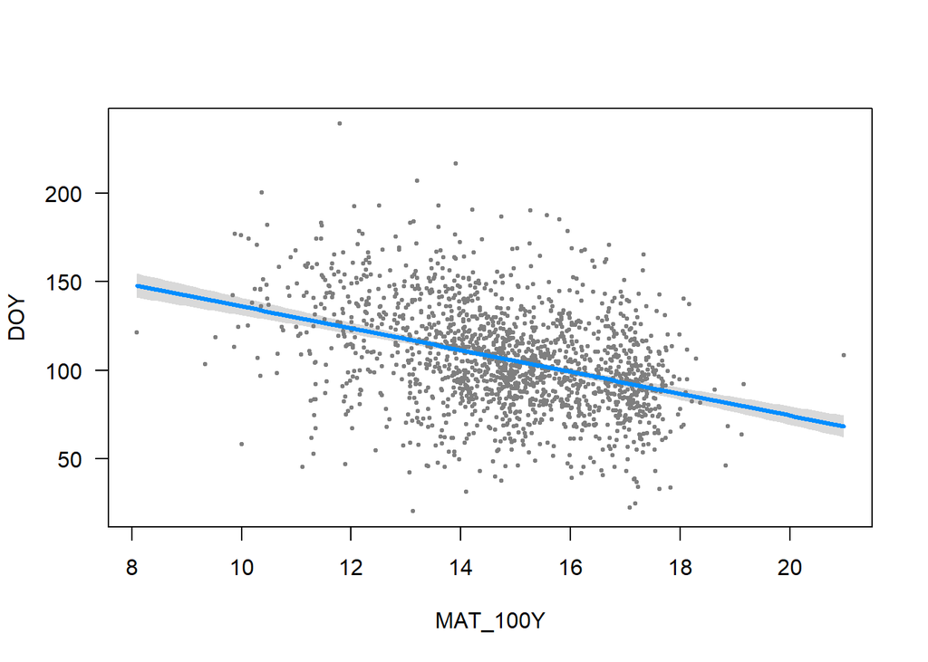

```
## Conditions used in construction of plot
## MAT_100Y: 14.891
## geo_f: n
```

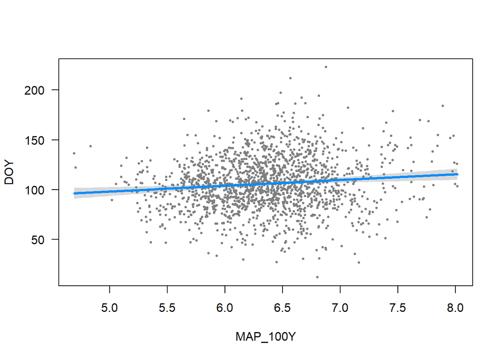

```
## Conditions used in construction of plot
## MAT_100Y: 14.891
## MAP_100Y: 6.348667
```

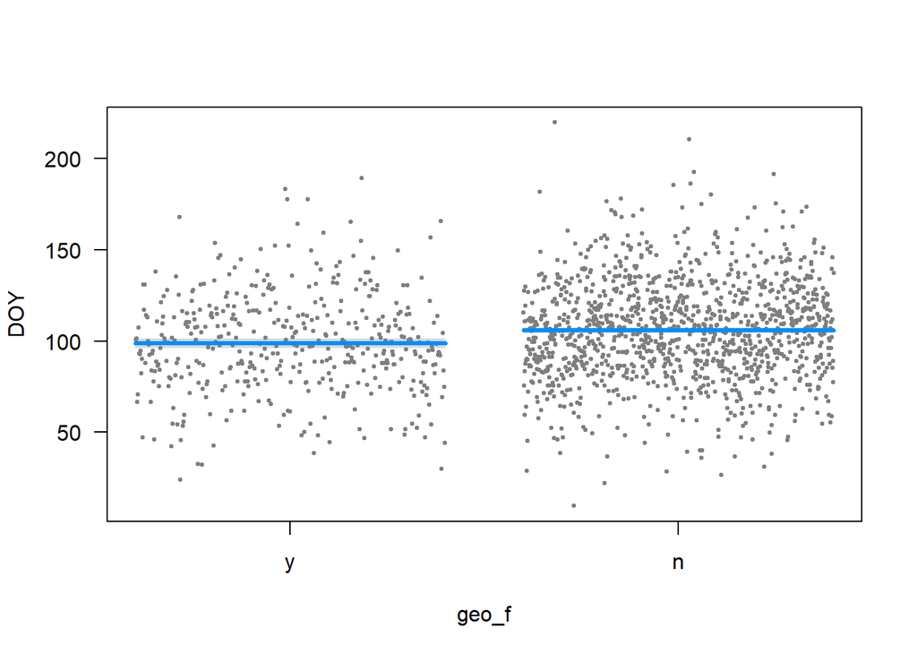

Appears that, as in above analyses, some aspect of georeference source (specimens we used GEOLocate to get coords for) results in a lower parameter estimate for temperature variables.

Other potential biases due to georeferencer

```r
#DOY
geo_lmg <- lm(DOY ~ geo_f, data = nemo_gby)
anova(geo_lmg)
```

```
## Analysis of Variance Table
##
## Response: DOY
##             Df  Sum Sq Mean Sq F value  Pr(>F)
## geo_f        1    4953  4952.6  5.7777 0.01634 *
## Residuals 1675 1435774   857.2
## ---
## Signif. codes:  0 '***' 0.001 '**' 0.01 '*' 0.05 '.' 0.1 ' ' 1
```

```r
#lat/long
geo_lmg1a <- lm(long ~ geo_f, data = nemo_gby)
geo_lmg1b <- lm(lat ~ geo_f, data = nemo_gby)
anova(geo_lmg1a)
```

```
## Analysis of Variance Table
##
## Response: long
##             Df Sum Sq Mean Sq F value    Pr(>F)
## geo_f        1 1196.9 1196.90  241.53 < 2.2e-16 ***
## Residuals 1675 8300.4    4.96
## ---
## Signif. codes:  0 '***' 0.001 '**' 0.01 '*' 0.05 '.' 0.1 ' ' 1
```

```r
anova(geo_lmg1b)
```

```
## Analysis of Variance Table
##
## Response: lat
##             Df Sum Sq Mean Sq F value    Pr(>F)
## geo_f        1  921.6  921.62  188.19 < 2.2e-16 ***
## Residuals 1675 8202.8    4.90
## ---
## Signif. codes:  0 '***' 0.001 '**' 0.01 '*' 0.05 '.' 0.1 ' ' 1
```

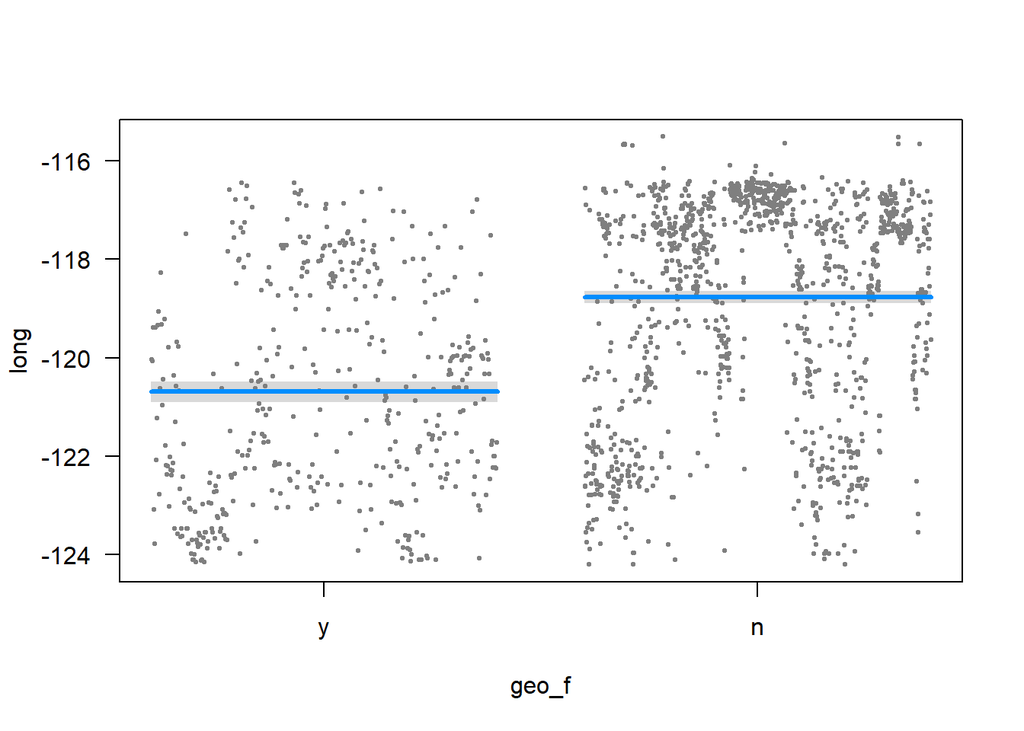

```r
visreg(geo_lmg1a) #wild pattern
```

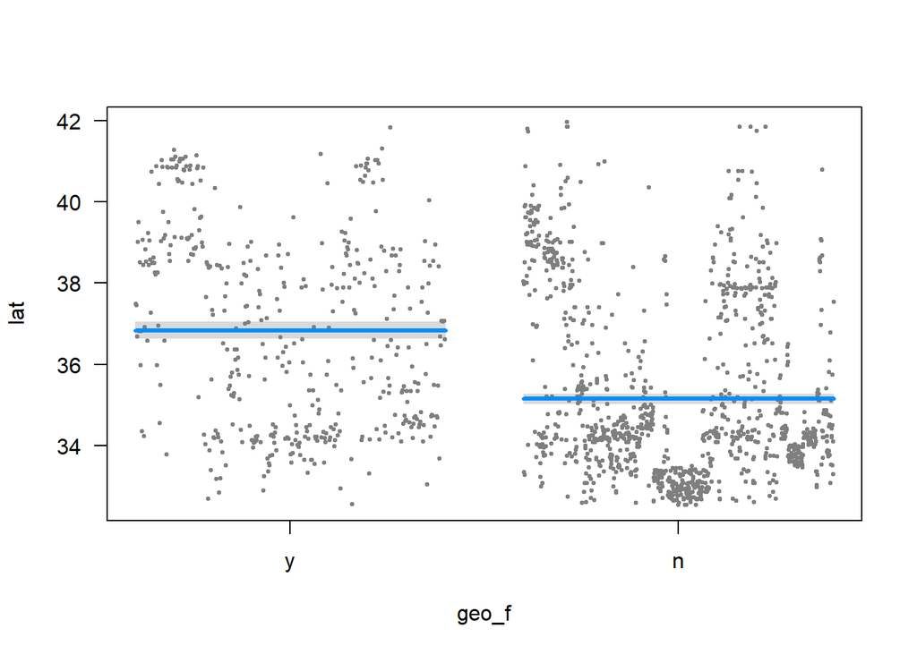

```r
visreg(geo_lmg1b)
```

```r
#year
geo_lmg2 <- lm(year ~ geo_f, data = nemo_gby)
anova(geo_lmg2)
```

```
## Analysis of Variance Table
##
## Response: year
##             Df  Sum Sq Mean Sq F value    Pr(>F)
## geo_f        1   74461   74461  73.364 < 2.2e-16 ***
## Residuals 1675 1700049    1015
## ---
## Signif. codes:  0 '***' 0.001 '**' 0.01 '*' 0.05 '.' 0.1 ' ' 1
```

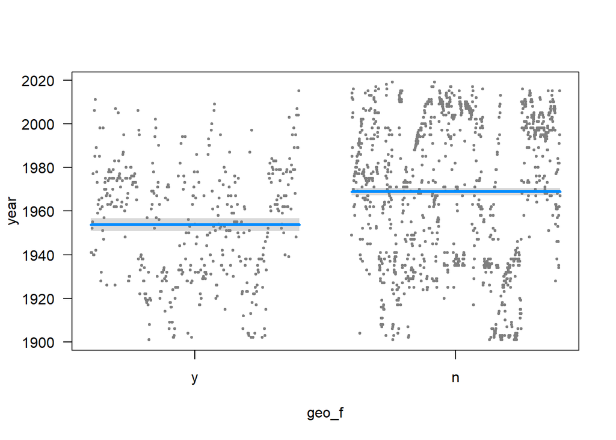

```r
visreg(geo_lmg2)
```

```r
#Elev_m
geo_lmg3 <- lm(elev_m ~ geo_f, data = nemo_gby)
anova(geo_lmg3)
```

```
## Analysis of Variance Table
##
## Response: elev_m
##             Df    Sum Sq  Mean Sq F value    Pr(>F)
## geo_f        1  14517280 14517280  64.886 1.492e-15 ***
## Residuals 1675 374754001   223734
## ---
## Signif. codes:  0 '***' 0.001 '**' 0.01 '*' 0.05 '.' 0.1 ' ' 1
```

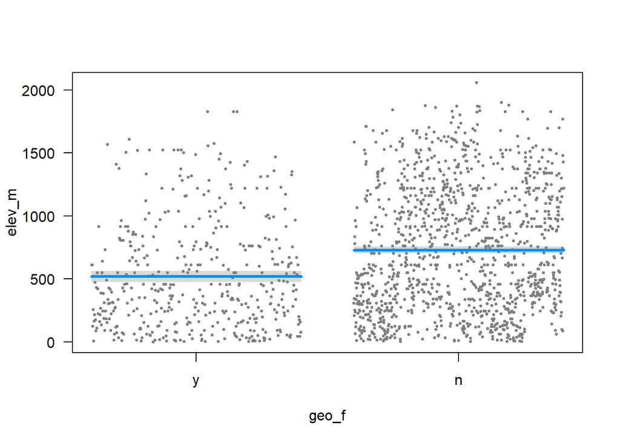

```r
visreg(geo_lmg3)
```

```r
#MAT
geo_lmg4 <- lm(MAT_100Y ~ geo_f, data = nemo_gby)
anova(geo_lmg4)
```

```
## Analysis of Variance Table
##
## Response: MAT_100Y
##             Df Sum Sq Mean Sq F value    Pr(>F)
## geo_f        1   59.7  59.696  18.922 1.444e-05 ***
## Residuals 1675 5284.3   3.155
## ---
## Signif. codes:  0 '***' 0.001 '**' 0.01 '*' 0.05 '.' 0.1 ' ' 1
```

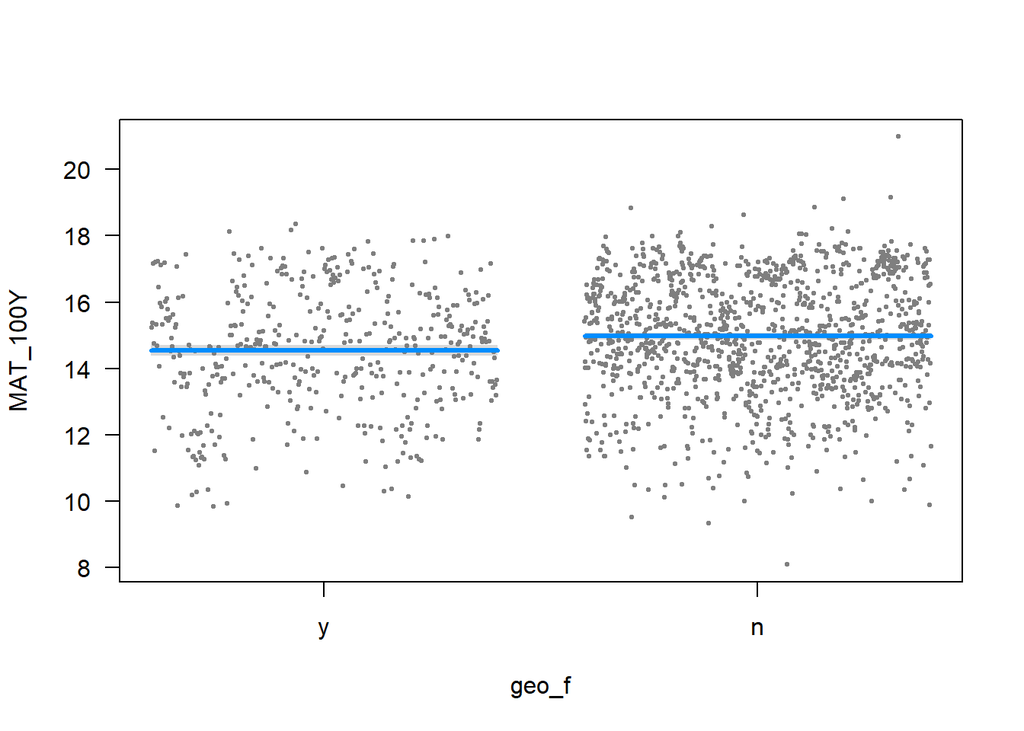

```r
visreg(geo_lmg4)
```

```r
#MAP
geo_lmg5 <- lm(MAP_100Y ~ geo_f, data = nemo_gby)
anova(geo_lmg5)
```

```
## Analysis of Variance Table
##
## Response: MAP_100Y
##             Df Sum Sq Mean Sq F value    Pr(>F)
## geo_f        1  19.86 19.8635  79.756 < 2.2e-16 ***
## Residuals 1675 417.17  0.2491
## ---
## Signif. codes:  0 '***' 0.001 '**' 0.01 '*' 0.05 '.' 0.1 ' ' 1
```

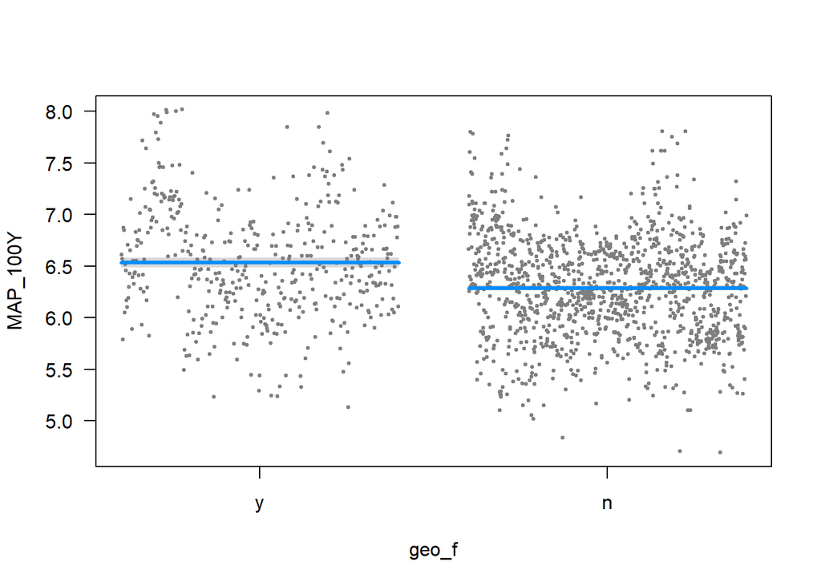

```r
visreg(geo_lmg5)
```

```r
#Similar pattern as with subsetting - significant effect when only-climate predictors, disappears when geographical predictors added
```

Significant differences in georeferencer source *suggests*:

- DOY earlier for geo_f = “y”
- Geographic biasd in non-georeferenced records (lat, long, elev_m)
- Year earlier for specimens we georeferenced
- Elevation lower for specimens we georeferenced
- MAT/temp cooler for geo_f = “y”

These geographic differences are enlightening! Help explain why it appears that temperature may differ between groups of georeferenced specimens.

### Other potential sources of noise aside from error distance or georeferenced location?

## Investigating Collection Bias on the relatinoship between climate and DOY

#### Year

Are there certain years or period with significantly higher collections? Has collections increased or decreased through time?

```r
cb_lm1 <- lm(DOY ~ year, data = nemo_df2)
summary(cb_lm1)
```

```
##
## Call:
## lm(formula = DOY ~ year, data = nemo_df2)
##
## Residuals:
##     Min      1Q  Median      3Q     Max
## -83.975 -19.966  -3.011  17.997 137.998
##
## Coefficients:
##               Estimate Std. Error t value Pr(>|t|)
## (Intercept)  1.058e+02  4.327e+01   2.445   0.0146 *
## year        -8.987e-04  2.202e-02  -0.041   0.9674
## ---
## Signif. codes:  0 '***' 0.001 '**' 0.01 '*' 0.05 '.' 0.1 ' ' 1
##
## Residual standard error: 29.33 on 1675 degrees of freedom
## Multiple R-squared:  9.948e-07,  Adjusted R-squared:  -0.000596
## F-statistic: 0.001666 on 1 and 1675 DF,  p-value: 0.9674
```

```r
#Correlate YoC with DOY collection to look for temporal collecting trend (as in Panchen 2019)

year_cor <- cor(nemo_df2 %>% select(DOY, year))
year_cor
```

```
##                DOY          year
## DOY   1.0000000000 -0.0009973724
## year -0.0009973724  1.0000000000
```

```r
#No correlation b/w DOY and year
```

No significant effect of year on DOY.

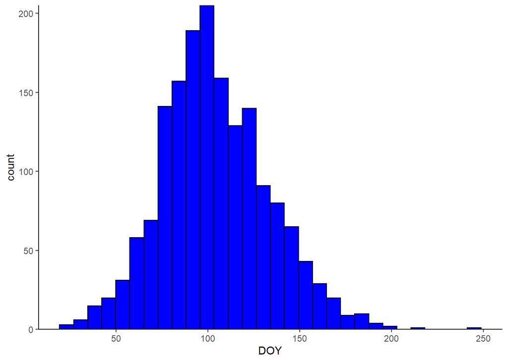

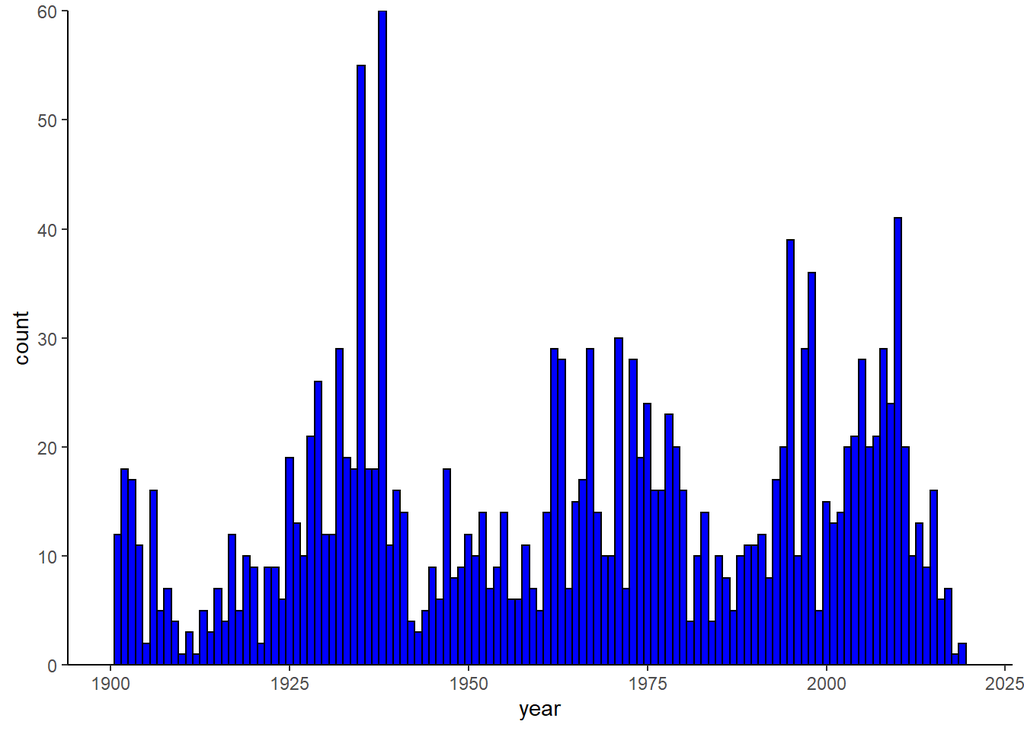

```r
#Number of specimens in each year - ID periods of low and high collection
ggplot(aes(x = year), data = nemo_df2) +
  geom_bar(stat = 'count', width = 1, fill = "blue", color = "black") +
  scale_y_continuous(expand = c(0,0)) +
  scale_x_continuous(limits = c(1900, 2020)) +
  theme_classic()
```

```r
#Parse by decade?
```

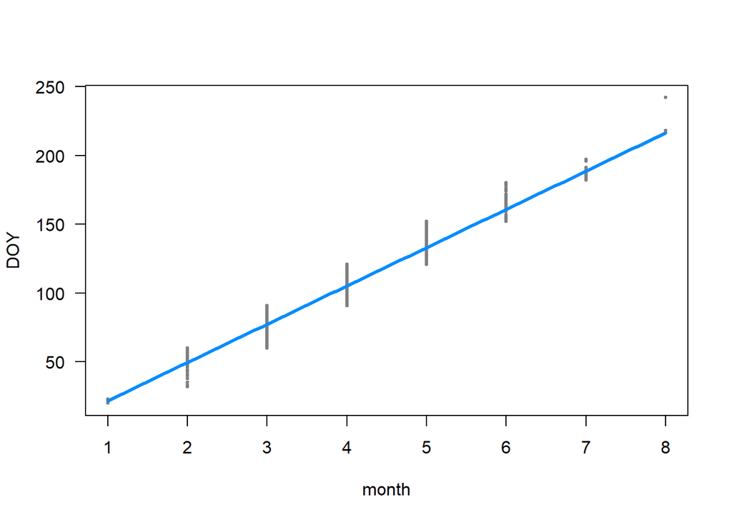

#### Location

Are certain parts of the species range sampled more heavily (e.g. Southeast)? Across years? Lat  
Long

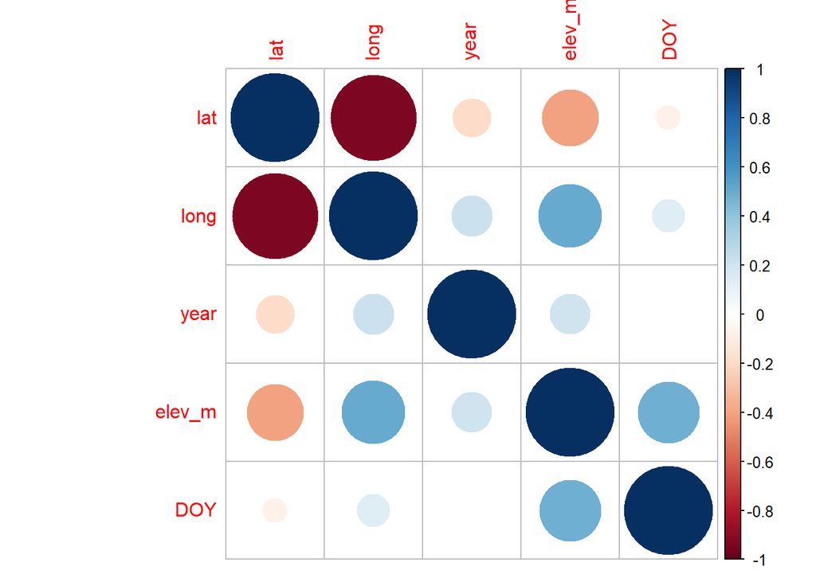

```
##
## Call:
## lm(formula = long ~ year + lat, data = nemo_df2)
##
## Residuals:
##     Min      1Q  Median      3Q     Max
## -2.0431 -0.5149  0.0906  0.5282  3.3260
##
## Coefficients:
##               Estimate Std. Error  t value Pr(>|t|)
## (Intercept) -9.164e+01  1.377e+00  -66.570  < 2e-16 ***
## year         3.035e-03  6.509e-04    4.663 3.37e-06 ***
## lat         -9.439e-01  9.077e-03 -103.997  < 2e-16 ***
## ---
## Signif. codes:  0 '***' 0.001 '**' 0.01 '*' 0.05 '.' 0.1 ' ' 1
##
## Residual standard error: 0.8517 on 1674 degrees of freedom
## Multiple R-squared:  0.8721, Adjusted R-squared:  0.872
## F-statistic:  5709 on 2 and 1674 DF,  p-value: < 2.2e-16
```

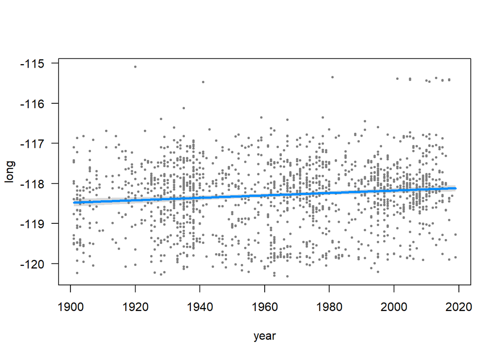

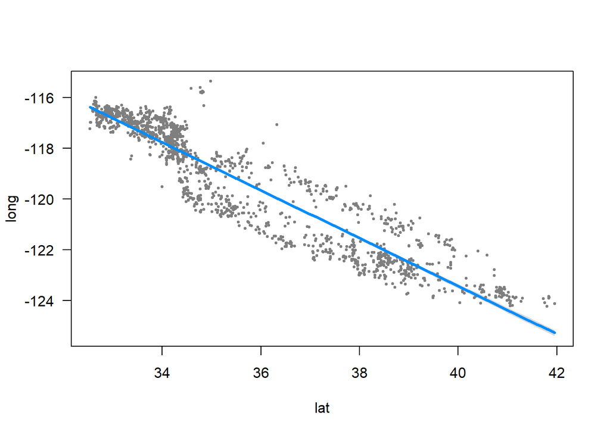

```
##
## Call:
## lm(formula = lat ~ year + long, data = nemo_df2)
##
## Residuals:
##      Min       1Q   Median       3Q      Max
## -1.99230 -0.46751 -0.04838  0.44695  2.88851
##
## Coefficients:
##               Estimate Std. Error  t value Pr(>|t|)
## (Intercept) -7.577e+01  1.813e+00  -41.784   <2e-16 ***
## year         9.860e-04  6.453e-04    1.528    0.127
## long        -9.174e-01  8.821e-03 -103.997   <2e-16 ***
## ---
## Signif. codes:  0 '***' 0.001 '**' 0.01 '*' 0.05 '.' 0.1 ' ' 1
##
## Residual standard error: 0.8396 on 1674 degrees of freedom
## Multiple R-squared:  0.8707, Adjusted R-squared:  0.8705
## F-statistic:  5634 on 2 and 1674 DF,  p-value: < 2.2e-16
```

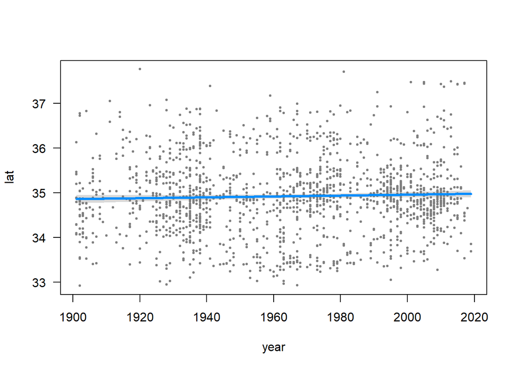

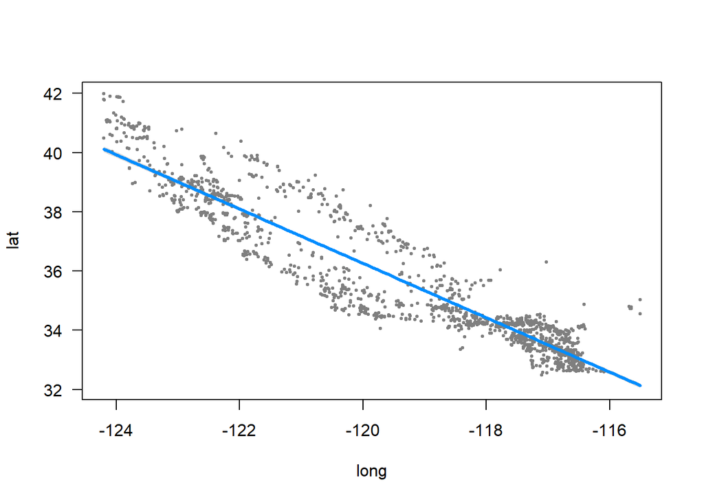

```
##
## Call:
## lm(formula = elev_m ~ year, data = nemo_df2)
##
## Residuals:
##    Min     1Q Median     3Q    Max
## -807.9 -394.4 -103.3  355.4 1477.3
##
## Coefficients:
##              Estimate Std. Error t value Pr(>|t|)
## (Intercept) -5356.600    695.754  -7.699 2.33e-14 ***
## year            3.069      0.354   8.669  < 2e-16 ***
## ---
## Signif. codes:  0 '***' 0.001 '**' 0.01 '*' 0.05 '.' 0.1 ' ' 1
##
## Residual standard error: 471.6 on 1675 degrees of freedom
## Multiple R-squared:  0.04294,    Adjusted R-squared:  0.04237
## F-statistic: 75.16 on 1 and 1675 DF,  p-value: < 2.2e-16
```

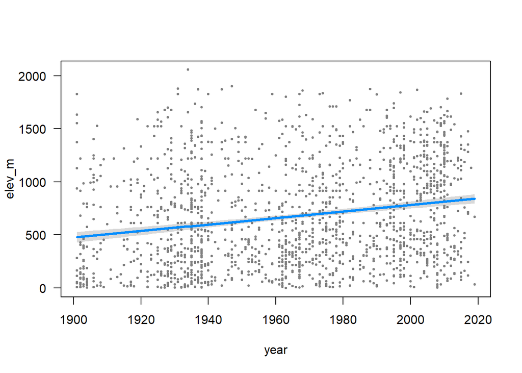

```
##
## Call:
## lm(formula = elev_m ~ year + long, data = nemo_df2)
##
## Residuals:
##     Min      1Q  Median      3Q     Max
## -937.30 -302.18  -62.56  271.23 1512.68
##
## Coefficients:
##              Estimate Std. Error t value Pr(>|t|)
## (Intercept) 9440.8325   890.3198  10.604  < 2e-16 ***
## year           1.5219     0.3169   4.803  1.7e-06 ***
## long          98.5725     4.3313  22.758  < 2e-16 ***
## ---
## Signif. codes:  0 '***' 0.001 '**' 0.01 '*' 0.05 '.' 0.1 ' ' 1
##
## Residual standard error: 412.3 on 1674 degrees of freedom
## Multiple R-squared:  0.2691, Adjusted R-squared:  0.2682
## F-statistic: 308.1 on 2 and 1674 DF,  p-value: < 2.2e-16
```

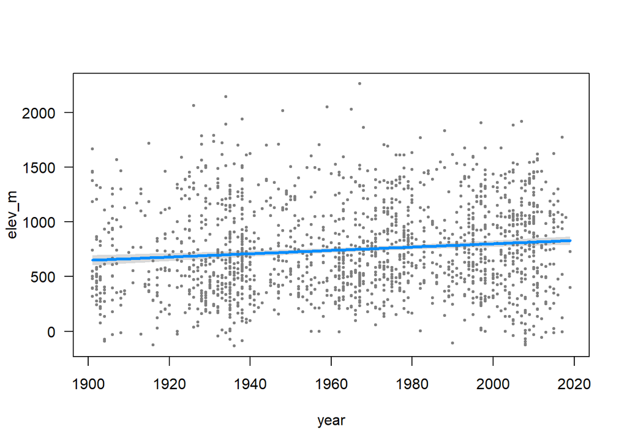

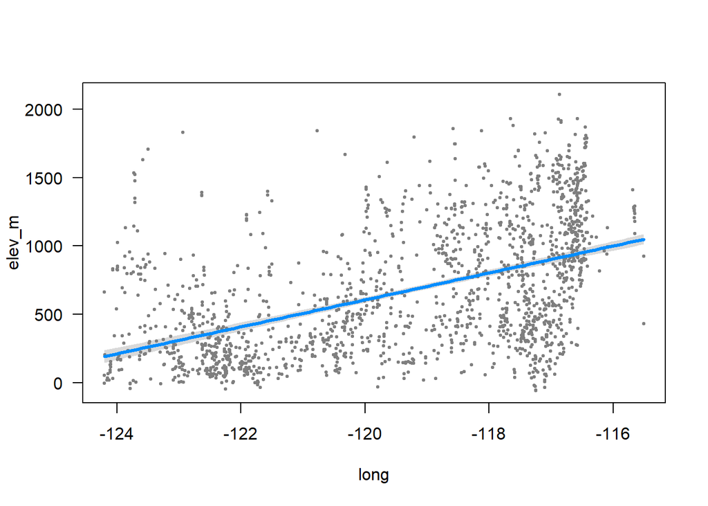

Over time, there appears to be relatively more collections made at more inland longitudes and at higher elevations. This could be do to greater collection efforts and greater accessibility to areas in more recent decades.

*Option*:  
Spatial Collection Patterns (Panchen 2019)  
- calculate density of specimens per [2500 m x 2500 m pixel]using `geosphere` package [or .25deg x .25deg - Daru 2018, sp package]  
- model relationship of density and distance to community (raster package) - [test for spatial autocorrelation to detect a temporal*spatial trend]

DOY as a response

```
##
## Call:
## lm(formula = DOY ~ lat, data = nemo_df2)
##
## Residuals:
##     Min      1Q  Median      3Q     Max
## -86.793 -19.221  -2.512  18.375 140.971
##
## Coefficients:
##             Estimate Std. Error t value Pr(>|t|)
## (Intercept) 137.9932    10.9195  12.637  < 2e-16 ***
## lat          -0.9548     0.3061  -3.119  0.00185 **
## ---
## Signif. codes:  0 '***' 0.001 '**' 0.01 '*' 0.05 '.' 0.1 ' ' 1
##
## Residual standard error: 29.24 on 1675 degrees of freedom
## Multiple R-squared:  0.005773,   Adjusted R-squared:  0.00518
## F-statistic: 9.726 on 1 and 1675 DF,  p-value: 0.001847
```

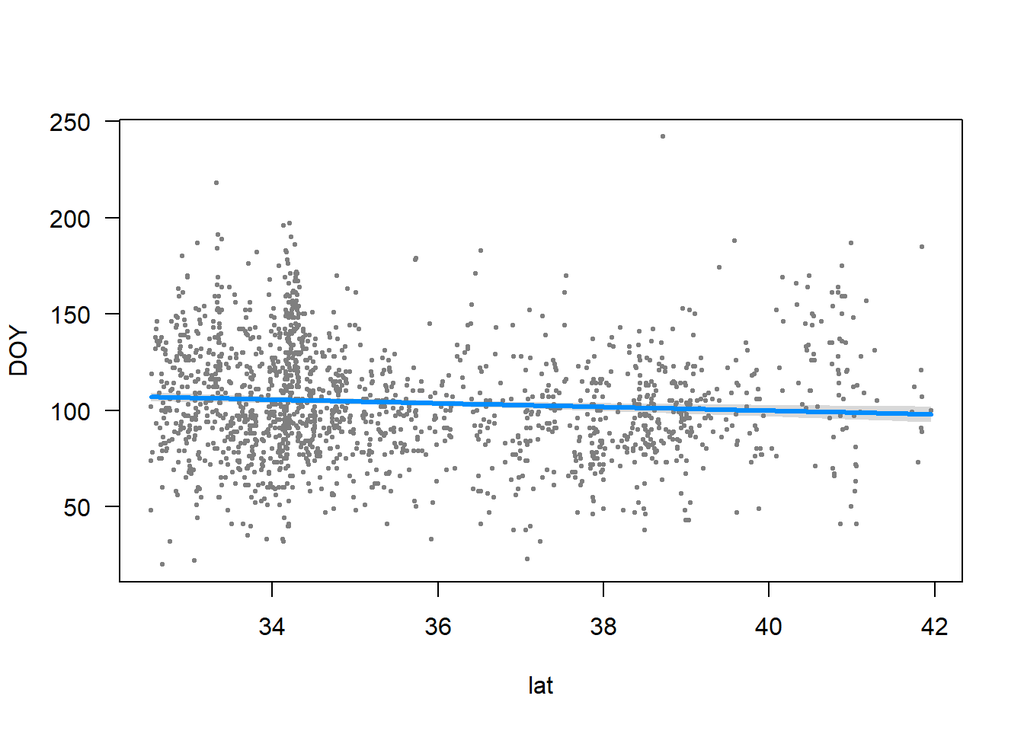

```
##
## Call:
## lm(formula = DOY ~ long, data = nemo_df2)
##
## Residuals:
##    Min     1Q Median     3Q    Max
## -88.08 -18.99  -2.16  17.70 145.04
##
## Coefficients:
##             Estimate Std. Error t value Pr(>|t|)
## (Intercept) 305.0813    35.5636   8.578  < 2e-16 ***
## long          1.6858     0.2981   5.655 1.83e-08 ***
## ---
## Signif. codes:  0 '***' 0.001 '**' 0.01 '*' 0.05 '.' 0.1 ' ' 1
##
## Residual standard error: 29.05 on 1675 degrees of freedom
## Multiple R-squared:  0.01873,    Adjusted R-squared:  0.01815
## F-statistic: 31.98 on 1 and 1675 DF,  p-value: 1.83e-08
```

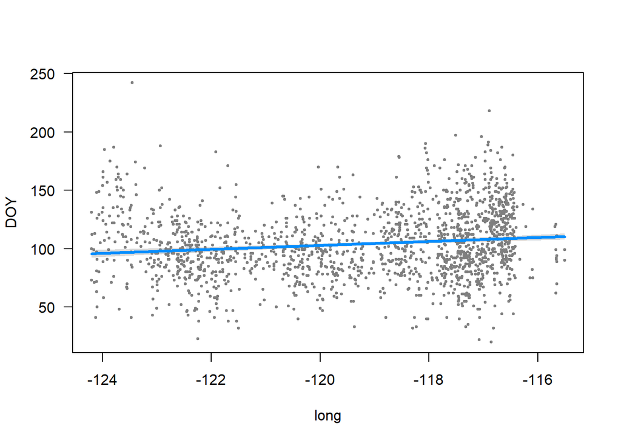

```
##
## Call:
## lm(formula = DOY ~ elev_m, data = nemo_df2)
##
## Residuals:
##     Min      1Q  Median      3Q     Max
## -78.178 -15.650  -1.192  15.467 156.651
##
## Coefficients:
##              Estimate Std. Error t value Pr(>|t|)
## (Intercept) 84.308256   1.080398   78.03   <2e-16 ***
## elev_m       0.029223   0.001304   22.41   <2e-16 ***
## ---
## Signif. codes:  0 '***' 0.001 '**' 0.01 '*' 0.05 '.' 0.1 ' ' 1
##
## Residual standard error: 25.72 on 1675 degrees of freedom
## Multiple R-squared:  0.2307, Adjusted R-squared:  0.2303
## F-statistic: 502.4 on 1 and 1675 DF,  p-value: < 2.2e-16
```

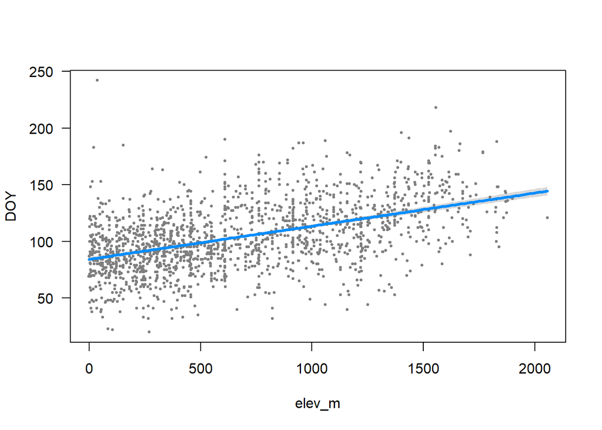

Multiple Variables:  
(Copied from ‘EDA2.Rmd’)

```
##
## Call:
## lm(formula = DOY ~ elev_m + long + year, data = nemo_df2)
##
## Residuals:
##     Min      1Q  Median      3Q     Max
## -82.910 -15.582  -1.128  15.397 154.005
##
## Coefficients:
##              Estimate Std. Error t value Pr(>|t|)
## (Intercept) 46.300290  56.545646   0.819    0.413
## elev_m       0.034443   0.001503  22.922  < 2e-16 ***
## long        -1.625230   0.304711  -5.334 1.09e-07 ***
## year        -0.081101   0.019615  -4.135 3.73e-05 ***
## ---
## Signif. codes:  0 '***' 0.001 '**' 0.01 '*' 0.05 '.' 0.1 ' ' 1
##
## Residual standard error: 25.35 on 1673 degrees of freedom
## Multiple R-squared:  0.254,  Adjusted R-squared:  0.2526
## F-statistic: 189.9 on 3 and 1673 DF,  p-value: < 2.2e-16
```

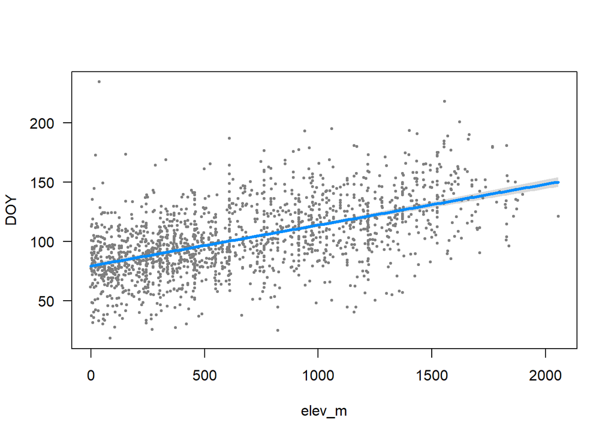

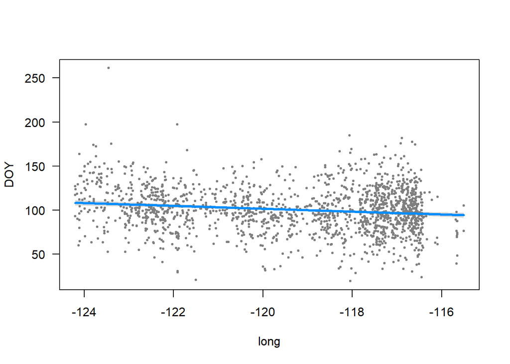

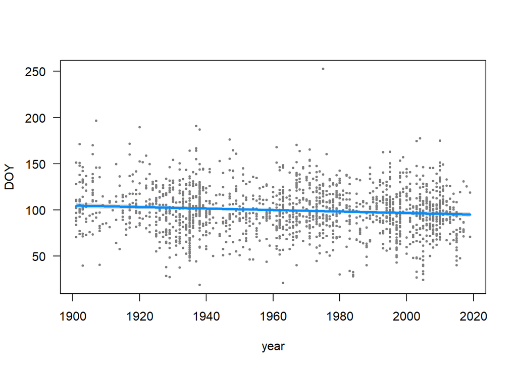

```
##
## Call:
## lm(formula = DOY ~ elev_m + year * long * lat, data = nemo_df2)
##
## Residuals:
##     Min      1Q  Median      3Q     Max
## -78.116 -15.943  -0.927  15.290 152.020
##
## Coefficients:
##                 Estimate Std. Error t value Pr(>|t|)
## (Intercept)    9.311e+04  3.883e+04   2.398   0.0166 *
## elev_m         3.297e-02  1.536e-03  21.460   <2e-16 ***
## year          -4.586e+01  1.981e+01  -2.315   0.0207 *
## long           7.712e+02  3.220e+02   2.395   0.0167 *
## lat           -2.589e+03  1.113e+03  -2.327   0.0201 *
## year:long     -3.801e-01  1.643e-01  -2.314   0.0208 *
## year:lat       1.275e+00  5.676e-01   2.246   0.0249 *
## long:lat      -2.147e+01  9.166e+00  -2.343   0.0193 *
## year:long:lat  1.057e-02  4.676e-03   2.260   0.0239 *
## ---
## Signif. codes:  0 '***' 0.001 '**' 0.01 '*' 0.05 '.' 0.1 ' ' 1
##
## Residual standard error: 25.11 on 1668 degrees of freedom
## Multiple R-squared:   0.27,  Adjusted R-squared:  0.2665
## F-statistic: 77.13 on 8 and 1668 DF,  p-value: < 2.2e-16
```

```
## Conditions used in construction of plot
## year: 1967
## long: -118.5411
## lat: 34.54328
```

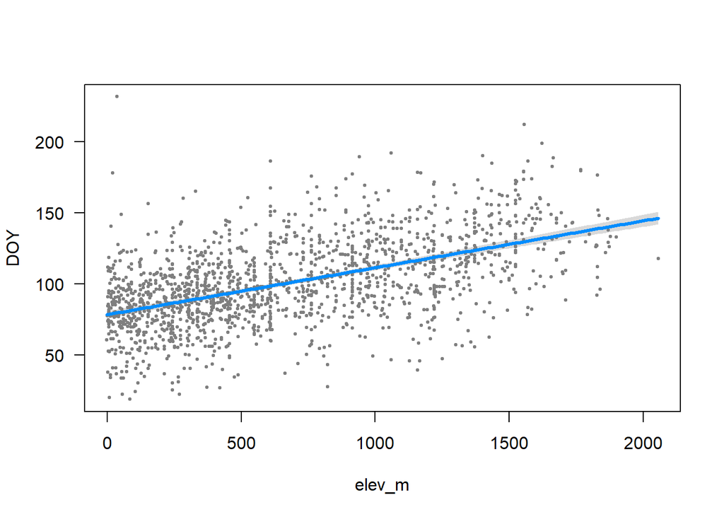

```
## Conditions used in construction of plot
## elev_m: 572.44
## long: -118.5411
## lat: 34.54328
```

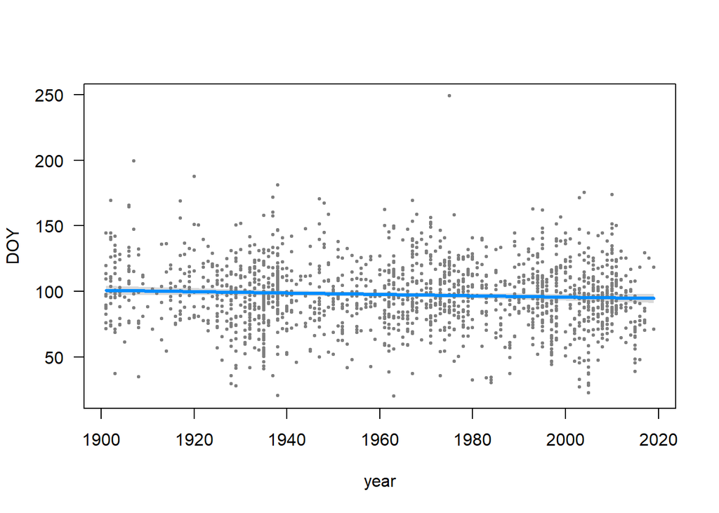

```
## Conditions used in construction of plot
## elev_m: 572.44
## year: 1967
## lat: 34.54328
```

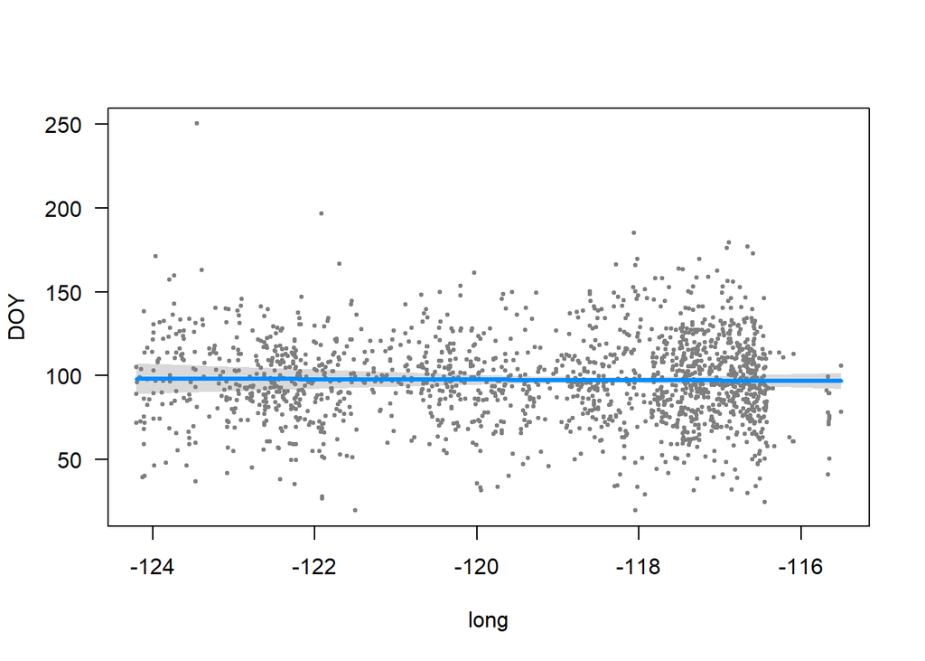

```
## Conditions used in construction of plot
## elev_m: 572.44
## year: 1967
## long: -118.5411
```

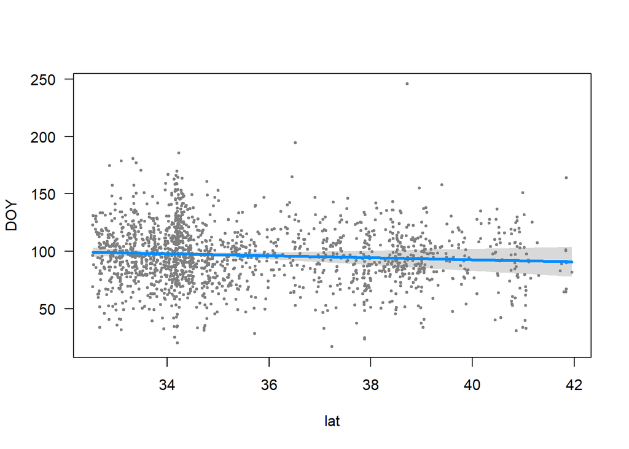

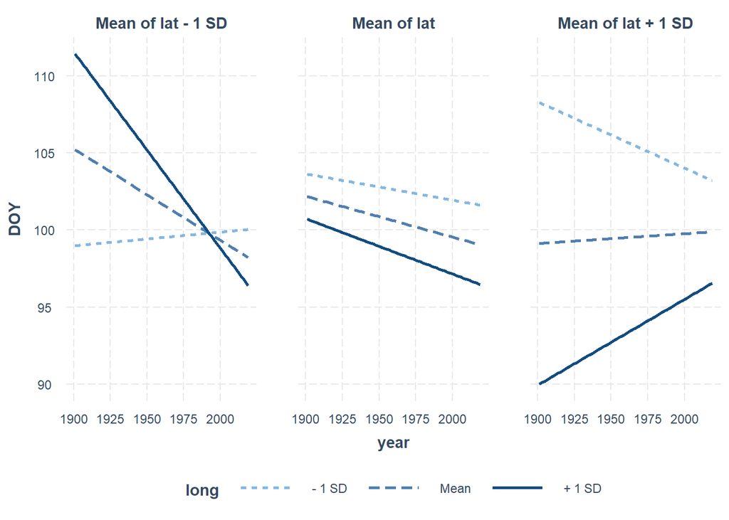

```
##
## Call:
## lm(formula = DOY ~ year * long * lat, data = nemo_df2)
##
## Residuals:
##     Min      1Q  Median      3Q     Max
## -84.890 -19.097  -0.691  17.165 146.650
##
## Coefficients:
##                 Estimate Std. Error t value Pr(>|t|)
## (Intercept)    1.727e+05  4.365e+04   3.955 7.96e-05 ***
## year          -8.569e+01  2.227e+01  -3.847 0.000124 ***
## long           1.432e+03  3.620e+02   3.955 7.98e-05 ***
## lat           -4.835e+03  1.251e+03  -3.865 0.000115 ***
## year:long     -7.103e-01  1.847e-01  -3.846 0.000125 ***
## year:lat       2.410e+00  6.382e-01   3.777 0.000165 ***
## long:lat      -4.008e+01  1.030e+01  -3.890 0.000104 ***
## year:long:lat  1.996e-02  5.258e-03   3.797 0.000152 ***
## ---
## Signif. codes:  0 '***' 0.001 '**' 0.01 '*' 0.05 '.' 0.1 ' ' 1
##
## Residual standard error: 28.36 on 1669 degrees of freedom
## Multiple R-squared:  0.06849,    Adjusted R-squared:  0.06458
## F-statistic: 17.53 on 7 and 1669 DF,  p-value: < 2.2e-16
```

```
## Conditions used in construction of plot
## long: -118.5411
## lat: 34.54328
```

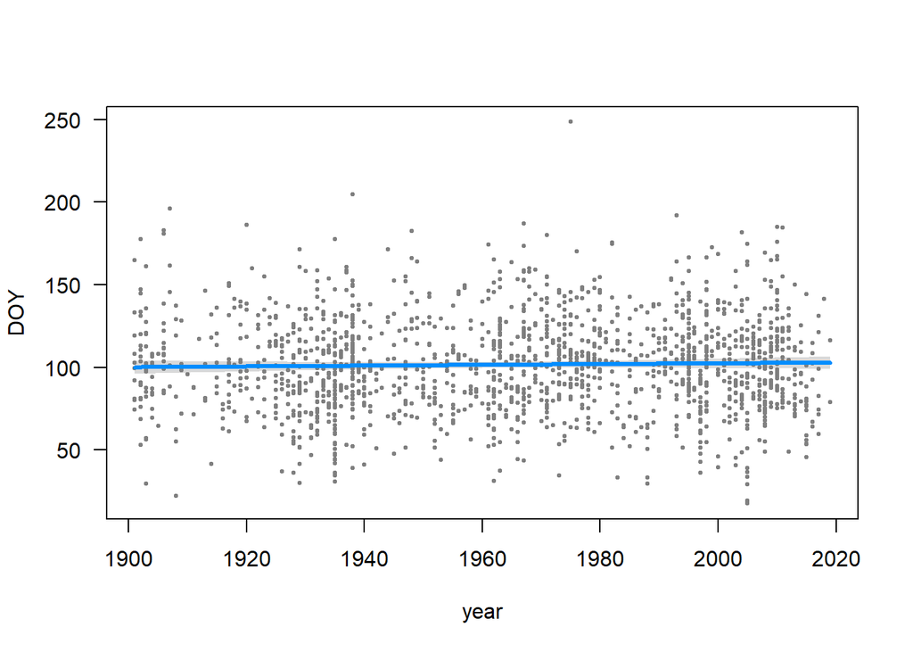

```
## Conditions used in construction of plot
## year: 1967
## lat: 34.54328
```

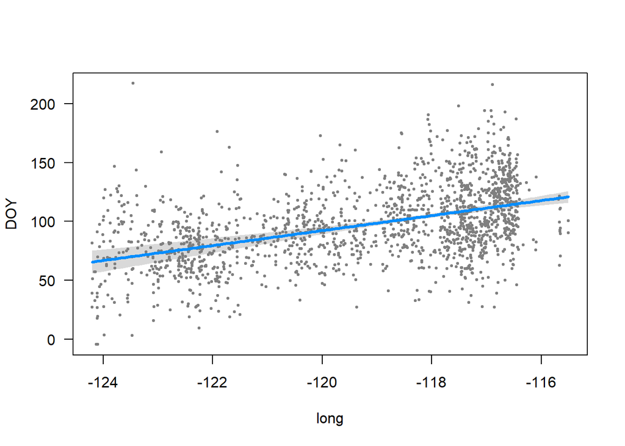

```
## Conditions used in construction of plot
## year: 1967
## long: -118.5411
```

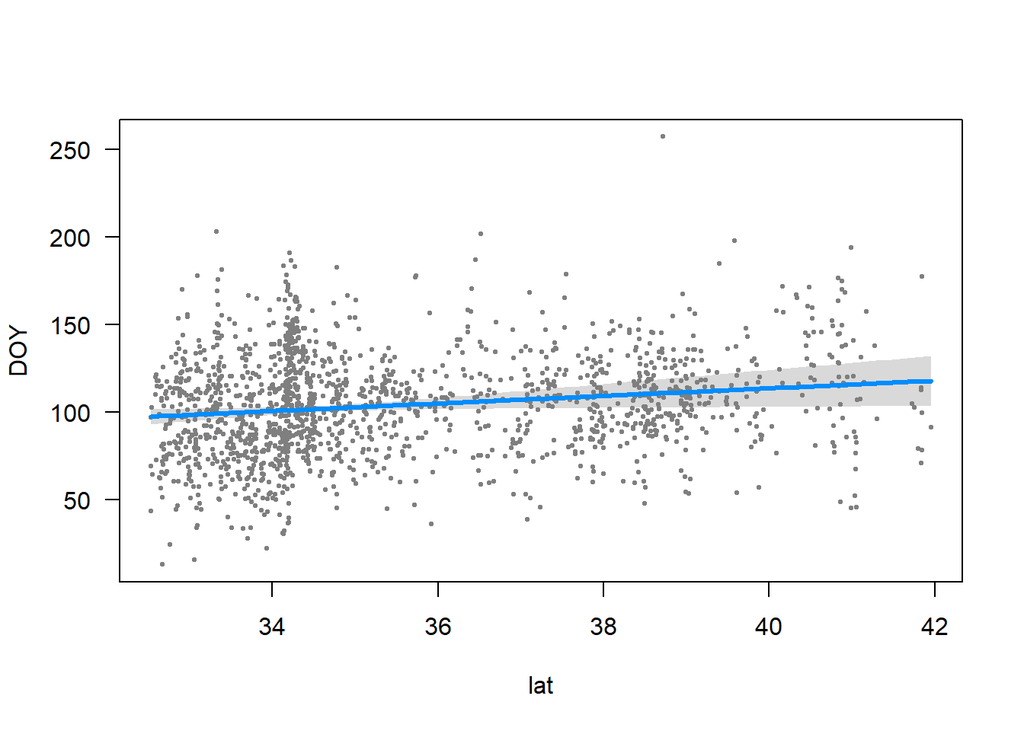

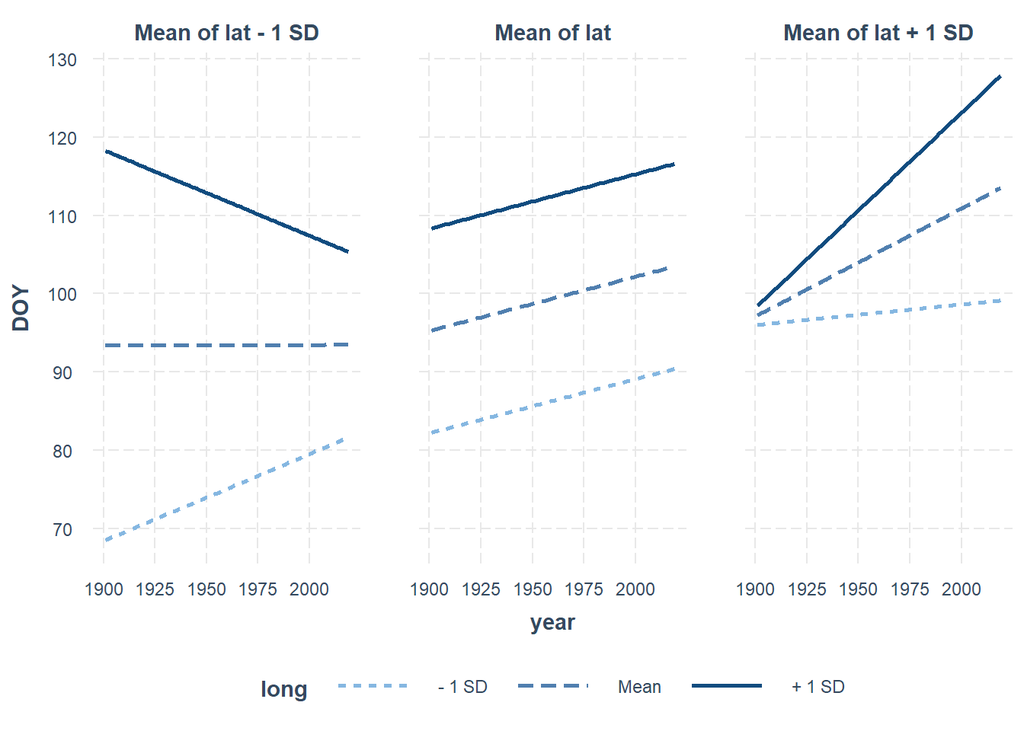

```
##
## Call:
## lm(formula = DOY ~ elev_m + year * long, data = nemo_df2)
##
## Residuals:
##     Min      1Q  Median      3Q     Max
## -82.907 -15.582  -1.125  15.398 154.000
##
## Coefficients:
##               Estimate Std. Error t value Pr(>|t|)
## (Intercept)  6.138e+01  1.912e+03   0.032    0.974
## elev_m       3.444e-02  1.503e-03  22.911   <2e-16 ***
## year        -8.879e-02  9.745e-01  -0.091    0.927
## long        -1.498e+00  1.607e+01  -0.093    0.926
## year:long   -6.461e-05  8.188e-03  -0.008    0.994
## ---
## Signif. codes:  0 '***' 0.001 '**' 0.01 '*' 0.05 '.' 0.1 ' ' 1
##
## Residual standard error: 25.35 on 1672 degrees of freedom
## Multiple R-squared:  0.254,  Adjusted R-squared:  0.2522
## F-statistic: 142.3 on 4 and 1672 DF,  p-value: < 2.2e-16
```

#### Collector Bias

Are there super-collectors who’ve collected a relatively large proportion of specimens?  
First name listed = primary collector (as in *Panchen 2019*) - Sort primary collectors by # specimens collected. Top collectors = those who collected XX% (e.g. 90%) of all specimens  
- calculate % of collectors top collectors represent  
- (over time: correlate top collectors mean # collections per year ~ collectors’ mean year of collecting)  
- (Mean DOY of top collectors - is it normally distributed? shapiro-wilks test. ID temporal biases)

**or**  
[Via Daru 2018 - multi-spp study..]  
- Calculate # specimens for each collector  
- Is this skewed toward few collectors?

```
## # A tibble: 6 x 4
##   collector_p1 Count Percent top_col
##   <chr>        <int>   <dbl> <chr>
## 1 Sanders         44    2.49 y
## 2 Gander          34    1.93 y
## 3 Swinney         30    1.70 y
## 4 Munz            27    1.53 y
## 5 Tracy           27    1.53 y
## 6 Rebman          26    1.47 y
```

```
##          n
## 1 2.215657
```

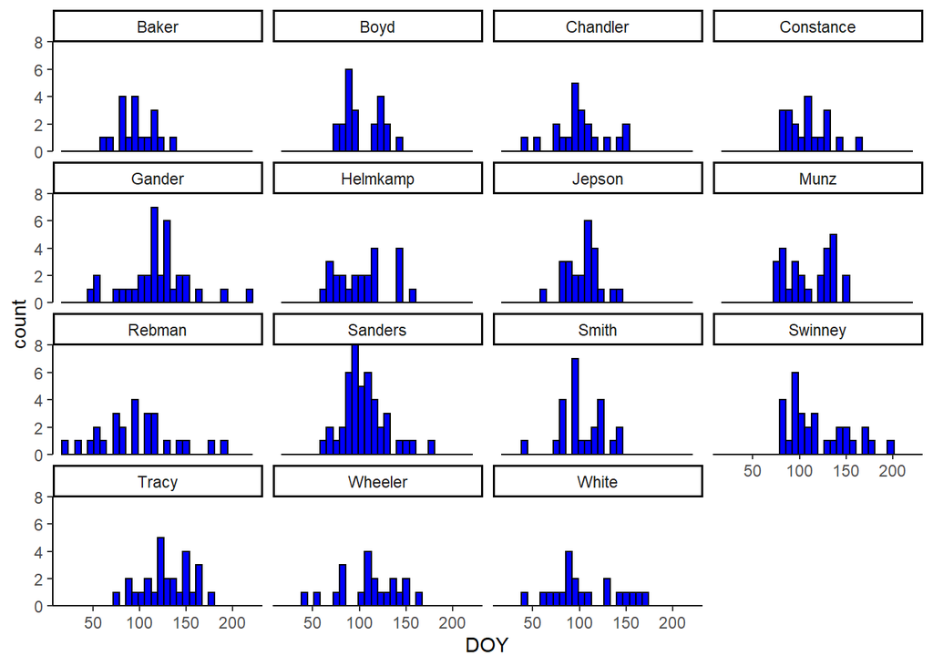

```
## # A tibble: 6 x 8
##   collector_p1 Count Percent Year_M Year_SE Year_Range  DOY_M DOY_SE
##   <chr>        <int>   <dbl>  <dbl>   <dbl> <chr>       <dbl>  <dbl>
## 1 Sanders         44    2.49  2002.   1.35  1973 , 2015 105.    3.50
## 2 Gander          34    1.93  1937.   0.349 1935 , 1941 120.    5.87
## 3 Swinney         30    1.70  1998.   1.54  1970 , 2011 120.    5.84
## 4 Munz            27    1.53  1926.   1.68  1918 , 1955 111.    4.92
## 5 Tracy           27    1.53  1925.   2.53  1902 , 1950 129.    4.97
## 6 Rebman          26    1.47  2006.   3.67  1917 , 2017  97.5   8.15
```

```
## [1] 382
```

Compare subsetted data (or with collector as covariate) to og data in pheno-climatic models?  
Not sure this makes sense, top collectors contributed a large number of records

```
##
## Call:
## lm(formula = DOY ~ MAT_100Y + MAP_100Y, data = nemo_df1_coll)
##
## Residuals:
##     Min      1Q  Median      3Q     Max
## -110.09  -17.18   -1.04   16.52  119.48
##
## Coefficients:
##             Estimate Std. Error t value Pr(>|t|)
## (Intercept) 168.5624    15.1050  11.159   <2e-16 ***
## MAT_100Y     -5.6739     0.4538 -12.503   <2e-16 ***
## MAP_100Y      3.0322     1.5852   1.913   0.0559 .
## ---
## Signif. codes:  0 '***' 0.001 '**' 0.01 '*' 0.05 '.' 0.1 ' ' 1
##
## Residual standard error: 27.31 on 1761 degrees of freedom
## Multiple R-squared:  0.1415, Adjusted R-squared:  0.1405
## F-statistic: 145.1 on 2 and 1761 DF,  p-value: < 2.2e-16
```

```
##
## Call:
## lm(formula = DOY ~ MAT_100Y + MAP_100Y, data = nemo_df1_notop)
##
## Residuals:
##      Min       1Q   Median       3Q      Max
## -108.034  -17.198   -1.078   16.460  121.701
##
## Coefficients:
##             Estimate Std. Error t value Pr(>|t|)
## (Intercept) 170.6896    16.9623  10.063   <2e-16 ***
## MAT_100Y     -5.5556     0.5101 -10.891   <2e-16 ***
## MAP_100Y      2.1975     1.7813   1.234    0.218
## ---
## Signif. codes:  0 '***' 0.001 '**' 0.01 '*' 0.05 '.' 0.1 ' ' 1
##
## Residual standard error: 27.4 on 1379 degrees of freedom
## Multiple R-squared:  0.1311, Adjusted R-squared:  0.1298
## F-statistic:   104 on 2 and 1379 DF,  p-value: < 2.2e-16
```

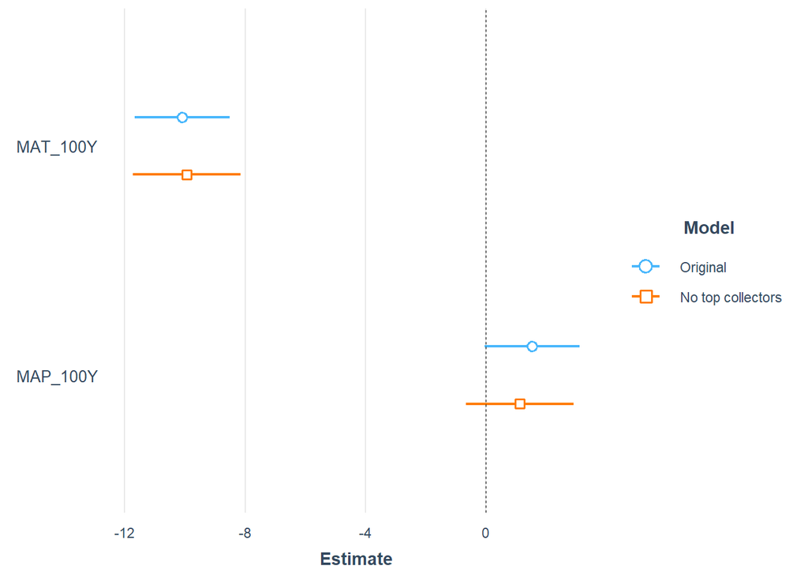

#### Phenological stage [when PI scoring complete]

Are certain phenophases (e.g. peak flowering) over-represented?  
(Are plants preferrentially collected during peak flowering) (Biases against v. early or late-stage phenophases)